# Predicting Electric Vehicle Energy Consumption: A Machine Learning Approach for Fleet Optimization

A transportation and logistics company is considering transitioning its fleet to electric vehicles to reduce costs. Before making this decision, the company seeks to predict the energy consumption of electric vehicles based on various usage factors and vehicle characteristics.

Using this publicly available real-world dataset, I will build a Machine Learning model capable of forecasting the energy consumption of electric vehicles. The model will take into account factors such as the type and number of electric motors, vehicle weight, payload capacity, and other attributes.

This project presents a significant challenge due to the dataset's small sample size and high dimensionality. To address this, I will employ specific ML models and techniques to mitigate overfitting and underfitting. It’s an exciting project with valuable insights that can pave the way for further exploration.

```python
import pandas as pd
import numpy as np
import pyreadstat
```

```python
pd.set_option('display.max_columns', 500)
df, meta = pyreadstat.read_sav('FEV-dataset-SPSS.sav')
df.head()
```

|  | CAR | Make | Model | Price | Power | Torque | Brakes | Drive | Battery | Range | Wheelbase | Length | Width | Height | Weight | Permissible_weight | Capacity | Seats | Doors | Tire_size | Max_speed | Boot_capacity | Acceleration | DC | Energy_consumption |
| --- | --- | --- | --- | --- | --- | --- | --- | --- | --- | --- | --- | --- | --- | --- | --- | --- | --- | --- | --- | --- | --- | --- | --- | --- | --- |
| 0 | Audi e-tron 55 quattro | Audi | e-tron 55 quattro | 345700.0 | 360.0 | 664.0 | disc (front + rear) | 4WD | 95.0 | 438.0 | 292.8 | 490.1 | 193.5 | 162.9 | 2565.0 | 3130.0 | 640.0 | 5.0 | 5.0 | 19.0 | 200.0 | 660.0 | 5.7 | 150.0 | 24.45 |
| 1 | Audi e-tron 50 quattro | Audi | e-tron 50 quattro | 308400.0 | 313.0 | 540.0 | disc (front + rear) | 4WD | 71.0 | 340.0 | 292.8 | 490.1 | 193.5 | 162.9 | 2445.0 | 3040.0 | 670.0 | 5.0 | 5.0 | 19.0 | 190.0 | 660.0 | 6.8 | 150.0 | 23.80 |
| 2 | Audi e-tron S quattro | Audi | e-tron S quattro | 414900.0 | 503.0 | 973.0 | disc (front + rear) | 4WD | 95.0 | 364.0 | 292.8 | 490.2 | 197.6 | 162.9 | 2695.0 | 3130.0 | 565.0 | 5.0 | 5.0 | 20.0 | 210.0 | 660.0 | 4.5 | 150.0 | 27.55 |
| 3 | Audi e-tron Sportback 50 quattro | Audi | e-tron Sportback 50 quattro | 319700.0 | 313.0 | 540.0 | disc (front + rear) | 4WD | 71.0 | 346.0 | 292.8 | 490.1 | 193.5 | 161.6 | 2445.0 | 3040.0 | 640.0 | 5.0 | 5.0 | 19.0 | 190.0 | 615.0 | 6.8 | 150.0 | 23.30 |
| 4 | Audi e-tron Sportback 55 quattro | Audi | e-tron Sportback 55 quattro | 357000.0 | 360.0 | 664.0 | disc (front + rear) | 4WD | 95.0 | 447.0 | 292.8 | 490.1 | 193.5 | 161.6 | 2595.0 | 3130.0 | 670.0 | 5.0 | 5.0 | 19.0 | 200.0 | 615.0 | 5.7 | 150.0 | 23.85 |

```python
df.info()
```

```
<class 'pandas.core.frame.DataFrame'>
RangeIndex: 53 entries, 0 to 52
Data columns (total 25 columns):
 #   Column              Non-Null Count  Dtype
---  ------              --------------  -----
 0   CAR                 53 non-null     object
 1   Make                53 non-null     object
 2   Model               53 non-null     object
 3   Price               53 non-null     float64
 4   Power               53 non-null     float64
 5   Torque              53 non-null     float64
 6   Brakes              52 non-null     object
 7   Drive               53 non-null     object
 8   Battery             53 non-null     float64
 9   Range               53 non-null     float64
```

[output cut: 17 more lines]

```python
# Cleaning the dataset by removing rows with missing values in the target variable 'Energy_consumption'
# and resetting the index to ensure a consistent structure for further analysis.

df.dropna(subset='Energy_consumption', axis=0, inplace=True)
df.reset_index(drop=True, inplace=True)
df.info()
```

```
<class 'pandas.core.frame.DataFrame'>
RangeIndex: 44 entries, 0 to 43
Data columns (total 25 columns):
 #   Column              Non-Null Count  Dtype
---  ------              --------------  -----
 0   CAR                 44 non-null     object
 1   Make                44 non-null     object
 2   Model               44 non-null     object
 3   Price               44 non-null     float64
 4   Power               44 non-null     float64
 5   Torque              44 non-null     float64
 6   Brakes              43 non-null     object
 7   Drive               44 non-null     object
 8   Battery             44 non-null     float64
 9   Range               44 non-null     float64
```

[output cut: 17 more lines]

```python
# Selecting and displaying the categorical variables from the dataset
lista_obj=df.columns[[0,1,2,6,7]].tolist()
df[lista_obj]
```

|  | CAR | Make | Model | Brakes | Drive |
| --- | --- | --- | --- | --- | --- |
| 0 | Audi e-tron 55 quattro | Audi | e-tron 55 quattro | disc (front + rear) | 4WD |
| 1 | Audi e-tron 50 quattro | Audi | e-tron 50 quattro | disc (front + rear) | 4WD |
| 2 | Audi e-tron S quattro | Audi | e-tron S quattro | disc (front + rear) | 4WD |
| 3 | Audi e-tron Sportback 50 quattro | Audi | e-tron Sportback 50 quattro | disc (front + rear) | 4WD |
| 4 | Audi e-tron Sportback 55 quattro | Audi | e-tron Sportback 55 quattro | disc (front + rear) | 4WD |
| 5 | Audi e-tron Sportback S quattro | Audi | e-tron Sportback S quattro | disc (front + rear) | 4WD |
| 6 | BMW i3 | BMW | i3 | disc (front + rear) | 2WD (rear) |
| 7 | BMW i3s | BMW | i3s | disc (front + rear) | 2WD (rear) |
| 8 | BMW iX3 | BMW | iX3 | disc (front + rear) | 2WD (rear) |
| 9 | DS DS3 Crossback e-tense | DS | DS3 Crossback e-tense | disc (front + rear) | 2WD (front) |
| 10 | Honda e | Honda | e | disc (front + rear) | 2WD (rear) |
| 11 | Honda e Advance | Honda | e Advance | disc (front + rear) | 2WD (rear) |
| 12 | Hyundai Ioniq electric | Hyundai | Ioniq electric | disc (front + rear) | 2WD (front) |
| 13 | Hyundai Kona electric 39.2kWh | Hyundai | Kona electric 39.2kWh | disc (front + rear) | 2WD (front) |
| 14 | Hyundai Kona electric 64kWh | Hyundai | Kona electric 64kWh | disc (front + rear) | 2WD (front) |
| 15 | Jaguar I-Pace | Jaguar | I-Pace | disc (front + rear) | 4WD |
| 16 | Kia e-Niro 39.2kWh | Kia | e-Niro 39.2kWh | disc (front + rear) | 2WD (front) |
| 17 | Kia e-Niro 64kWh | Kia | e-Niro 64kWh | disc (front + rear) | 2WD (front) |
| 18 | Kia e-Soul 39.2kWh | Kia | e-Soul 39.2kWh | disc (front + rear) | 2WD (front) |
| 19 | Kia e-Soul 64kWh | Kia | e-Soul 64kWh | disc (front + rear) | 2WD (front) |
| 20 | Mazda MX-30 | Mazda | MX-30 | disc (front + rear) | 2WD (front) |
| 21 | Mercedes-Benz EQC | Mercedes-Benz | EQC | disc (front + rear) | 4WD |
| 22 | Mini Cooper SE | Mini | Cooper SE | disc (front + rear) | 2WD (front) |
| 23 | Nissan Leaf | Nissan | Leaf | disc (front + rear) | 2WD (front) |
| 24 | Nissan Leaf e+ | Nissan | Leaf e+ | disc (front + rear) | 2WD (front) |
| 25 | Opel Corsa-e | Opel | Corsa-e | disc (front + rear) | 2WD (front) |
| 26 | Opel Mokka-e | Opel | Mokka-e | disc (front + rear) | 2WD (front) |
| 27 | Peugeot e-208 | Peugeot | e-208 | disc (front + rear) | 2WD (front) |
| 28 | Porsche Taycan 4S (Performance) | Porsche | Taycan 4S (Performance) | disc (front + rear) | 4WD |
| 29 | Porsche Taycan 4S (Performance Plus) | Porsche | Taycan 4S (Performance Plus) | disc (front + rear) | 4WD |
| 30 | Porsche Taycan Turbo | Porsche | Taycan Turbo | disc (front + rear) | 4WD |
| 31 | Porsche Taycan Turbo S | Porsche | Taycan Turbo S | disc (front + rear) | 4WD |
| 32 | Renault Zoe R110 | Renault | Zoe R110 | disc (front + rear) | 2WD (front) |
| 33 | Renault Zoe R135 | Renault | Zoe R135 | disc (front + rear) | 2WD (front) |
| 34 | Skoda Citigo-e iV | Skoda | Citigo-e iV | disc (front) + drum (rear) | 2WD (front) |
| 35 | Smart fortwo EQ | Smart | fortwo EQ | disc (front) + drum (rear) | 2WD (rear) |
| 36 | Smart forfour EQ | Smart | forfour EQ | disc (front) + drum (rear) | 2WD (rear) |
| 37 | Volkswagen e-up! | Volkswagen | e-up! | disc (front) + drum (rear) | 2WD (front) |
| 38 | Volkswagen ID.3 Pro Performance | Volkswagen | ID.3 Pro Performance | disc (front) + drum (rear) | 2WD (rear) |
| 39 | Volkswagen ID.3 Pro S | Volkswagen | ID.3 Pro S | disc (front) + drum (rear) | 2WD (rear) |
| 40 | Volkswagen ID.4 1st | Volkswagen | ID.4 1st | disc (front) + drum (rear) | 2WD (rear) |
| 41 | Citroën ë-Spacetourer (M) | Citroën | ë-Spacetourer (M) | disc (front + rear) | 2WD (front) |
| 42 | Mercedes-Benz EQV (long) | Mercedes-Benz | EQV (long) | NaN | 2WD (front) |
| 43 | Nissan e-NV200 evalia | Nissan | e-NV200 evalia | disc (front + rear) | 2WD (front) |

In the cell containing NaN in the "Brakes" column, we will impute the value "disc (front + rear)" since, after a quick search, we deduced that this is the most likely brake system for this model.

```python
# Filling missing values in the 'Brakes' column with a default value ('disc (front + rear)')
# to ensure there are no null values in the categorical variables.
df['Brakes'] = df['Brakes'].fillna('disc (front + rear)')
df[lista_obj]
```

|  | CAR | Make | Model | Brakes | Drive |
| --- | --- | --- | --- | --- | --- |
| 0 | Audi e-tron 55 quattro | Audi | e-tron 55 quattro | disc (front + rear) | 4WD |
| 1 | Audi e-tron 50 quattro | Audi | e-tron 50 quattro | disc (front + rear) | 4WD |
| 2 | Audi e-tron S quattro | Audi | e-tron S quattro | disc (front + rear) | 4WD |
| 3 | Audi e-tron Sportback 50 quattro | Audi | e-tron Sportback 50 quattro | disc (front + rear) | 4WD |
| 4 | Audi e-tron Sportback 55 quattro | Audi | e-tron Sportback 55 quattro | disc (front + rear) | 4WD |
| 5 | Audi e-tron Sportback S quattro | Audi | e-tron Sportback S quattro | disc (front + rear) | 4WD |
| 6 | BMW i3 | BMW | i3 | disc (front + rear) | 2WD (rear) |
| 7 | BMW i3s | BMW | i3s | disc (front + rear) | 2WD (rear) |
| 8 | BMW iX3 | BMW | iX3 | disc (front + rear) | 2WD (rear) |
| 9 | DS DS3 Crossback e-tense | DS | DS3 Crossback e-tense | disc (front + rear) | 2WD (front) |
| 10 | Honda e | Honda | e | disc (front + rear) | 2WD (rear) |
| 11 | Honda e Advance | Honda | e Advance | disc (front + rear) | 2WD (rear) |
| 12 | Hyundai Ioniq electric | Hyundai | Ioniq electric | disc (front + rear) | 2WD (front) |
| 13 | Hyundai Kona electric 39.2kWh | Hyundai | Kona electric 39.2kWh | disc (front + rear) | 2WD (front) |
| 14 | Hyundai Kona electric 64kWh | Hyundai | Kona electric 64kWh | disc (front + rear) | 2WD (front) |
| 15 | Jaguar I-Pace | Jaguar | I-Pace | disc (front + rear) | 4WD |
| 16 | Kia e-Niro 39.2kWh | Kia | e-Niro 39.2kWh | disc (front + rear) | 2WD (front) |
| 17 | Kia e-Niro 64kWh | Kia | e-Niro 64kWh | disc (front + rear) | 2WD (front) |
| 18 | Kia e-Soul 39.2kWh | Kia | e-Soul 39.2kWh | disc (front + rear) | 2WD (front) |
| 19 | Kia e-Soul 64kWh | Kia | e-Soul 64kWh | disc (front + rear) | 2WD (front) |
| 20 | Mazda MX-30 | Mazda | MX-30 | disc (front + rear) | 2WD (front) |
| 21 | Mercedes-Benz EQC | Mercedes-Benz | EQC | disc (front + rear) | 4WD |
| 22 | Mini Cooper SE | Mini | Cooper SE | disc (front + rear) | 2WD (front) |
| 23 | Nissan Leaf | Nissan | Leaf | disc (front + rear) | 2WD (front) |
| 24 | Nissan Leaf e+ | Nissan | Leaf e+ | disc (front + rear) | 2WD (front) |
| 25 | Opel Corsa-e | Opel | Corsa-e | disc (front + rear) | 2WD (front) |
| 26 | Opel Mokka-e | Opel | Mokka-e | disc (front + rear) | 2WD (front) |
| 27 | Peugeot e-208 | Peugeot | e-208 | disc (front + rear) | 2WD (front) |
| 28 | Porsche Taycan 4S (Performance) | Porsche | Taycan 4S (Performance) | disc (front + rear) | 4WD |
| 29 | Porsche Taycan 4S (Performance Plus) | Porsche | Taycan 4S (Performance Plus) | disc (front + rear) | 4WD |
| 30 | Porsche Taycan Turbo | Porsche | Taycan Turbo | disc (front + rear) | 4WD |
| 31 | Porsche Taycan Turbo S | Porsche | Taycan Turbo S | disc (front + rear) | 4WD |
| 32 | Renault Zoe R110 | Renault | Zoe R110 | disc (front + rear) | 2WD (front) |
| 33 | Renault Zoe R135 | Renault | Zoe R135 | disc (front + rear) | 2WD (front) |
| 34 | Skoda Citigo-e iV | Skoda | Citigo-e iV | disc (front) + drum (rear) | 2WD (front) |
| 35 | Smart fortwo EQ | Smart | fortwo EQ | disc (front) + drum (rear) | 2WD (rear) |
| 36 | Smart forfour EQ | Smart | forfour EQ | disc (front) + drum (rear) | 2WD (rear) |
| 37 | Volkswagen e-up! | Volkswagen | e-up! | disc (front) + drum (rear) | 2WD (front) |
| 38 | Volkswagen ID.3 Pro Performance | Volkswagen | ID.3 Pro Performance | disc (front) + drum (rear) | 2WD (rear) |
| 39 | Volkswagen ID.3 Pro S | Volkswagen | ID.3 Pro S | disc (front) + drum (rear) | 2WD (rear) |
| 40 | Volkswagen ID.4 1st | Volkswagen | ID.4 1st | disc (front) + drum (rear) | 2WD (rear) |
| 41 | Citroën ë-Spacetourer (M) | Citroën | ë-Spacetourer (M) | disc (front + rear) | 2WD (front) |
| 42 | Mercedes-Benz EQV (long) | Mercedes-Benz | EQV (long) | disc (front + rear) | 2WD (front) |
| 43 | Nissan e-NV200 evalia | Nissan | e-NV200 evalia | disc (front + rear) | 2WD (front) |

After analyzing the columns of type object, we will adopt the following strategies based on the number of records and the relevance of the variables:

**CAR** column: We decided to drop this column as it contains only names that have no direct relationship with the target variable. Keeping this information could introduce noise into the model without adding predictive value.

**Make** column: Although this variable has the potential to contribute, applying one-hot encoding would be risky due to the limited number of records, especially since some brands have very few occurrences. Therefore, we will consider this strategy:

- Group less frequent categories as "Other": This reduces dimensionality without completely discarding the variable.

**Model** column: The direct relationship between model and make, along with the large number of unique values, makes this column redundant and confusing for the model. We will drop it.

**Brakes** columns: Since it has only two unique values (disc (front) + drum (rear) and disc (front + rear)) , we will apply one-hot encoding because this encoding is lightweight and will not burden the model.

**Drive** column: Since it has only three unique values (4wd, 2wd (front), and 2wd (rear)), we will apply one-hot encoding because this encoding is lightweight and will not burden the model.

```python
df.columns
```

```
Index(['CAR', 'Make', 'Model', 'Price', 'Power', 'Torque', 'Brakes', 'Drive',
       'Battery', 'Range', 'Wheelbase', 'Length', 'Width', 'Height', 'Weight',
       'Permissible_weight', 'Capacity', 'Seats', 'Doors', 'Tire_size',
       'Max_speed', 'Boot_capacity', 'Acceleration', 'DC',
       'Energy_consumption'],
      dtype='object')
```

```python
#Dropping CAR and Model
df1=df.copy()
df1.drop(columns=['CAR', 'Model'], inplace=True)
df1.head()
```

|  | Make | Price | Power | Torque | Brakes | Drive | Battery | Range | Wheelbase | Length | Width | Height | Weight | Permissible_weight | Capacity | Seats | Doors | Tire_size | Max_speed | Boot_capacity | Acceleration | DC | Energy_consumption |
| --- | --- | --- | --- | --- | --- | --- | --- | --- | --- | --- | --- | --- | --- | --- | --- | --- | --- | --- | --- | --- | --- | --- | --- |
| 0 | Audi | 345700.0 | 360.0 | 664.0 | disc (front + rear) | 4WD | 95.0 | 438.0 | 292.8 | 490.1 | 193.5 | 162.9 | 2565.0 | 3130.0 | 640.0 | 5.0 | 5.0 | 19.0 | 200.0 | 660.0 | 5.7 | 150.0 | 24.45 |
| 1 | Audi | 308400.0 | 313.0 | 540.0 | disc (front + rear) | 4WD | 71.0 | 340.0 | 292.8 | 490.1 | 193.5 | 162.9 | 2445.0 | 3040.0 | 670.0 | 5.0 | 5.0 | 19.0 | 190.0 | 660.0 | 6.8 | 150.0 | 23.80 |
| 2 | Audi | 414900.0 | 503.0 | 973.0 | disc (front + rear) | 4WD | 95.0 | 364.0 | 292.8 | 490.2 | 197.6 | 162.9 | 2695.0 | 3130.0 | 565.0 | 5.0 | 5.0 | 20.0 | 210.0 | 660.0 | 4.5 | 150.0 | 27.55 |
| 3 | Audi | 319700.0 | 313.0 | 540.0 | disc (front + rear) | 4WD | 71.0 | 346.0 | 292.8 | 490.1 | 193.5 | 161.6 | 2445.0 | 3040.0 | 640.0 | 5.0 | 5.0 | 19.0 | 190.0 | 615.0 | 6.8 | 150.0 | 23.30 |
| 4 | Audi | 357000.0 | 360.0 | 664.0 | disc (front + rear) | 4WD | 95.0 | 447.0 | 292.8 | 490.1 | 193.5 | 161.6 | 2595.0 | 3130.0 | 670.0 | 5.0 | 5.0 | 19.0 | 200.0 | 615.0 | 5.7 | 150.0 | 23.85 |

```python
counts=df1['Make'].value_counts()
counts
```

```
Make
Audi             6
Porsche          4
Volkswagen       4
Kia              4
Hyundai          3
BMW              3
Nissan           3
Honda            2
Smart            2
Mercedes-Benz    2
Opel             2
Renault          2
Skoda            1
Mini             1
Peugeot          1
Mazda            1
Jaguar           1
DS               1
Citroën          1
Name: count, dtype: int64
```

```python
#Grouping less frequent categories as "Other"
df1['Make'] = df1['Make'].apply(lambda x: 'other' if counts[x] < 3 else x)
```

```python
df1['Make'].value_counts()
```

```
Make
other         17
Audi           6
Kia            4
Porsche        4
Volkswagen     4
BMW            3
Hyundai        3
Nissan         3
Name: count, dtype: int64
```

```python
#Applying one-hot encoding
df1 = pd.get_dummies(df1, columns=['Make','Brakes', 'Drive'])
```

```python
df1.columns
```

```
Index(['Price', 'Power', 'Torque', 'Battery', 'Range', 'Wheelbase', 'Length',
       'Width', 'Height', 'Weight', 'Permissible_weight', 'Capacity', 'Seats',
       'Doors', 'Tire_size', 'Max_speed', 'Boot_capacity', 'Acceleration',
       'DC', 'Energy_consumption', 'Make_Audi', 'Make_BMW', 'Make_Hyundai',
       'Make_Kia', 'Make_Nissan', 'Make_Porsche', 'Make_Volkswagen',
       'Make_other', 'Brakes_disc (front + rear)',
       'Brakes_disc (front) + drum (rear)', 'Drive_2WD (front)',
       'Drive_2WD (rear)', 'Drive_4WD'],
      dtype='object')
```

```python
df1[['Make_Audi', 'Make_BMW', 'Make_Hyundai',
       'Make_Kia', 'Make_Nissan', 'Make_Porsche', 'Make_Volkswagen',
       'Make_other', 'Brakes_disc (front + rear)',
       'Brakes_disc (front) + drum (rear)', 'Drive_2WD (front)',
       'Drive_2WD (rear)', 'Drive_4WD']]=df1[['Make_Audi', 'Make_BMW', 'Make_Hyundai',
       'Make_Kia', 'Make_Nissan', 'Make_Porsche', 'Make_Volkswagen',
       'Make_other', 'Brakes_disc (front + rear)',
       'Brakes_disc (front) + drum (rear)', 'Drive_2WD (front)',
       'Drive_2WD (rear)', 'Drive_4WD']].astype(int)
df1
```

|  | Price | Power | Torque | Battery | Range | Wheelbase | Length | Width | Height | Weight | Permissible_weight | Capacity | Seats | Doors | Tire_size | Max_speed | Boot_capacity | Acceleration | DC | Energy_consumption | Make_Audi | Make_BMW | Make_Hyundai | Make_Kia | Make_Nissan | Make_Porsche | Make_Volkswagen | Make_other | Brakes_disc (front + rear) | … |
| --- | --- | --- | --- | --- | --- | --- | --- | --- | --- | --- | --- | --- | --- | --- | --- | --- | --- | --- | --- | --- | --- | --- | --- | --- | --- | --- | --- | --- | --- | --- |
| 0 | 345700.0 | 360.0 | 664.0 | 95.0 | 438.0 | 292.8 | 490.1 | 193.5 | 162.9 | 2565.0 | 3130.0 | 640.0 | 5.0 | 5.0 | 19.0 | 200.0 | 660.0 | 5.7 | 150.0 | 24.45 | 1 | 0 | 0 | 0 | 0 | 0 | 0 | 0 | 1 | … |
| 1 | 308400.0 | 313.0 | 540.0 | 71.0 | 340.0 | 292.8 | 490.1 | 193.5 | 162.9 | 2445.0 | 3040.0 | 670.0 | 5.0 | 5.0 | 19.0 | 190.0 | 660.0 | 6.8 | 150.0 | 23.80 | 1 | 0 | 0 | 0 | 0 | 0 | 0 | 0 | 1 | … |
| 2 | 414900.0 | 503.0 | 973.0 | 95.0 | 364.0 | 292.8 | 490.2 | 197.6 | 162.9 | 2695.0 | 3130.0 | 565.0 | 5.0 | 5.0 | 20.0 | 210.0 | 660.0 | 4.5 | 150.0 | 27.55 | 1 | 0 | 0 | 0 | 0 | 0 | 0 | 0 | 1 | … |
| 3 | 319700.0 | 313.0 | 540.0 | 71.0 | 346.0 | 292.8 | 490.1 | 193.5 | 161.6 | 2445.0 | 3040.0 | 640.0 | 5.0 | 5.0 | 19.0 | 190.0 | 615.0 | 6.8 | 150.0 | 23.30 | 1 | 0 | 0 | 0 | 0 | 0 | 0 | 0 | 1 | … |
| 4 | 357000.0 | 360.0 | 664.0 | 95.0 | 447.0 | 292.8 | 490.1 | 193.5 | 161.6 | 2595.0 | 3130.0 | 670.0 | 5.0 | 5.0 | 19.0 | 200.0 | 615.0 | 5.7 | 150.0 | 23.85 | 1 | 0 | 0 | 0 | 0 | 0 | 0 | 0 | 1 | … |
| 5 | 426200.0 | 503.0 | 973.0 | 95.0 | 369.0 | 292.8 | 490.2 | 197.6 | 161.5 | 2695.0 | 3130.0 | 565.0 | 5.0 | 5.0 | 20.0 | 210.0 | 615.0 | 4.5 | 150.0 | 27.20 | 1 | 0 | 0 | 0 | 0 | 0 | 0 | 0 | 1 | … |
| 6 | 169700.0 | 170.0 | 250.0 | 42.2 | 359.0 | 257.0 | 400.6 | 179.1 | 157.0 | 1440.0 | 1730.0 | 440.0 | 4.0 | 5.0 | 19.0 | 160.0 | 260.0 | 8.1 | 50.0 | 13.10 | 0 | 1 | 0 | 0 | 0 | 0 | 0 | 0 | 1 | … |
| 7 | 184200.0 | 184.0 | 270.0 | 42.2 | 345.0 | 257.0 | 400.6 | 179.1 | 159.0 | 1460.0 | 1730.0 | 440.0 | 4.0 | 5.0 | 20.0 | 160.0 | 260.0 | 6.9 | 50.0 | 14.30 | 0 | 1 | 0 | 0 | 0 | 0 | 0 | 0 | 1 | … |
| 8 | 282900.0 | 286.0 | 400.0 | 80.0 | 460.0 | 286.4 | 473.4 | 189.1 | 166.8 | 2260.0 | 2725.0 | 540.0 | 5.0 | 5.0 | 19.0 | 180.0 | 510.0 | 6.8 | 150.0 | 18.80 | 0 | 1 | 0 | 0 | 0 | 0 | 0 | 0 | 1 | … |
| 9 | 159900.0 | 136.0 | 260.0 | 50.0 | 320.0 | 255.8 | 411.8 | 255.8 | 153.4 | 1523.0 | 1975.0 | 450.0 | 5.0 | 5.0 | 17.0 | 150.0 | 350.0 | 8.7 | 100.0 | 15.60 | 0 | 0 | 0 | 0 | 0 | 0 | 0 | 1 | 1 | … |
| 10 | 152900.0 | 136.0 | 315.0 | 35.5 | 222.0 | 253.8 | 389.4 | 175.2 | 151.2 | 1514.0 | 1855.0 | 342.0 | 5.0 | 5.0 | 16.0 | 145.0 | 171.0 | 9.0 | 100.0 | 17.20 | 0 | 0 | 0 | 0 | 0 | 0 | 0 | 1 | 1 | … |
| 11 | 165900.0 | 154.0 | 315.0 | 35.5 | 222.0 | 253.8 | 389.4 | 175.2 | 151.2 | 1543.0 | 1870.0 | 350.0 | 5.0 | 5.0 | 17.0 | 145.0 | 171.0 | 8.3 | 100.0 | 17.50 | 0 | 0 | 0 | 0 | 0 | 0 | 0 | 1 | 1 | … |
| 12 | 184500.0 | 136.0 | 295.0 | 38.3 | 311.0 | 270.0 | 447.0 | 182.0 | 147.5 | 1527.0 | 1970.0 | 518.0 | 5.0 | 5.0 | 16.0 | 165.0 | 357.0 | 9.9 | 100.0 | 13.80 | 0 | 0 | 1 | 0 | 0 | 0 | 0 | 0 | 1 | … |
| 13 | 154400.0 | 136.0 | 395.0 | 39.2 | 289.0 | 260.0 | 418.0 | 180.0 | 157.0 | 1535.0 | 2020.0 | 485.0 | 5.0 | 5.0 | 17.0 | 155.0 | 332.0 | 9.7 | 100.0 | 15.00 | 0 | 0 | 1 | 0 | 0 | 0 | 0 | 0 | 1 | … |
| 14 | 178400.0 | 204.0 | 395.0 | 64.0 | 449.0 | 260.0 | 418.0 | 180.0 | 157.0 | 1685.0 | 2170.0 | 485.0 | 5.0 | 5.0 | 17.0 | 167.0 | 332.0 | 7.6 | 100.0 | 15.40 | 0 | 0 | 1 | 0 | 0 | 0 | 0 | 0 | 1 | … |
| 15 | 359500.0 | 400.0 | 696.0 | 90.0 | 470.0 | 299.0 | 468.2 | 201.1 | 155.6 | 2208.0 | 2670.0 | 537.0 | 5.0 | 5.0 | 20.0 | 200.0 | 656.0 | 4.8 | 100.0 | 21.20 | 0 | 0 | 0 | 0 | 0 | 0 | 0 | 1 | 1 | … |
| 16 | 146990.0 | 136.0 | 395.0 | 39.2 | 289.0 | 270.0 | 437.5 | 180.5 | 156.0 | 1592.0 | 2080.0 | 488.0 | 5.0 | 5.0 | 17.0 | 155.0 | 451.0 | 9.8 | 100.0 | 15.30 | 0 | 0 | 0 | 1 | 0 | 0 | 0 | 0 | 1 | … |
| 17 | 167990.0 | 204.0 | 395.0 | 64.0 | 455.0 | 270.0 | 437.5 | 180.5 | 156.0 | 1737.0 | 2230.0 | 493.0 | 5.0 | 5.0 | 17.0 | 167.0 | 451.0 | 7.8 | 100.0 | 15.90 | 0 | 0 | 0 | 1 | 0 | 0 | 0 | 0 | 1 | … |
| 18 | 139900.0 | 136.0 | 395.0 | 39.2 | 276.0 | 260.0 | 419.5 | 180.0 | 160.5 | 1535.0 | 1682.0 | 490.0 | 5.0 | 5.0 | 17.0 | 157.0 | 315.0 | 9.9 | 100.0 | 15.60 | 0 | 0 | 0 | 1 | 0 | 0 | 0 | 0 | 1 | … |
| 19 | 160990.0 | 204.0 | 395.0 | 64.0 | 452.0 | 260.0 | 419.5 | 180.0 | 160.5 | 1535.0 | 1682.0 | 498.0 | 5.0 | 5.0 | 17.0 | 167.0 | 315.0 | 7.9 | 100.0 | 15.70 | 0 | 0 | 0 | 1 | 0 | 0 | 0 | 0 | 1 | … |
| 20 | 142900.0 | 145.0 | 270.0 | 35.5 | 200.0 | 265.5 | 439.5 | 179.5 | 155.5 | 1645.0 | 2119.0 | 474.0 | 5.0 | 5.0 | 18.0 | 140.0 | 350.0 | 9.7 | 37.0 | 14.50 | 0 | 0 | 0 | 0 | 0 | 0 | 0 | 1 | 1 | … |
| 21 | 334700.0 | 408.0 | 760.0 | 80.0 | 414.0 | 287.3 | 476.2 | 188.4 | 162.4 | 2495.0 | 2940.0 | 445.0 | 5.0 | 5.0 | 19.0 | 180.0 | 500.0 | 5.1 | 110.0 | 21.85 | 0 | 0 | 0 | 0 | 0 | 0 | 0 | 1 | 1 | … |
| 22 | 139900.0 | 184.0 | 270.0 | 28.9 | 234.0 | 249.5 | 384.5 | 172.7 | 143.2 | 1300.0 | 1770.0 | 480.0 | 4.0 | 3.0 | 16.0 | 150.0 | 211.0 | 7.3 | 50.0 | 16.75 | 0 | 0 | 0 | 0 | 0 | 0 | 0 | 1 | 1 | … |
| 23 | 122900.0 | 150.0 | 320.0 | 40.0 | 270.0 | 270.0 | 449.0 | 178.8 | 153.0 | 1545.0 | 1995.0 | 450.0 | 5.0 | 5.0 | 16.0 | 144.0 | 435.0 | 7.9 | 50.0 | 18.50 | 0 | 0 | 0 | 0 | 1 | 0 | 0 | 0 | 1 | … |
| 24 | 164000.0 | 217.0 | 340.0 | 62.0 | 385.0 | 270.0 | 449.0 | 178.8 | 154.5 | 1705.0 | 2140.0 | 435.0 | 5.0 | 5.0 | 17.0 | 157.0 | 435.0 | 6.9 | 100.0 | 17.10 | 0 | 0 | 0 | 0 | 1 | 0 | 0 | 0 | 1 | … |
| 25 | 128900.0 | 136.0 | 260.0 | 50.0 | 337.0 | 253.8 | 406.0 | 176.5 | 143.3 | 1530.0 | 1916.0 | 367.0 | 5.0 | 5.0 | 16.0 | 150.0 | 267.0 | 8.1 | 100.0 | 16.65 | 0 | 0 | 0 | 0 | 0 | 0 | 0 | 1 | 1 | … |
| 26 | 139900.0 | 136.0 | 260.0 | 50.0 | 324.0 | 256.1 | 415.1 | 179.1 | 153.2 | 1598.0 | 2015.0 | 417.0 | 5.0 | 5.0 | 16.0 | 150.0 | 310.0 | 9.0 | 100.0 | 17.60 | 0 | 0 | 0 | 0 | 0 | 0 | 0 | 1 | 1 | … |
| 27 | 124900.0 | 136.0 | 260.0 | 50.0 | 340.0 | 254.0 | 405.5 | 174.5 | 143.0 | 1455.0 | 1918.0 | 463.0 | 5.0 | 5.0 | 16.0 | 150.0 | 311.0 | 8.1 | 100.0 | 16.40 | 0 | 0 | 0 | 0 | 0 | 0 | 0 | 1 | 1 | … |
| 28 | 457000.0 | 435.0 | 640.0 | 79.2 | 407.0 | 290.0 | 496.3 | 196.6 | 137.9 | 2215.0 | 2880.0 | 740.0 | 4.0 | 4.0 | 19.0 | 250.0 | 488.0 | 4.0 | 225.0 | 23.40 | 0 | 0 | 0 | 0 | 0 | 1 | 0 | 0 | 1 | … |
| 29 | 482283.0 | 490.0 | 650.0 | 93.4 | 463.0 | 290.0 | 496.3 | 196.6 | 137.9 | 2295.0 | 2880.0 | 660.0 | 4.0 | 4.0 | 19.0 | 250.0 | 488.0 | 4.0 | 270.0 | 24.10 | 0 | 0 | 0 | 0 | 0 | 1 | 0 | 0 | 1 | … |
| 30 | 653000.0 | 625.0 | 850.0 | 93.4 | 450.0 | 290.0 | 496.3 | 196.6 | 138.1 | 2380.0 | 2880.0 | 575.0 | 4.0 | 4.0 | 20.0 | 260.0 | 447.0 | 3.2 | 270.0 | 24.85 | 0 | 0 | 0 | 0 | 0 | 1 | 0 | 0 | 1 | … |
| 31 | 794000.0 | 625.0 | 1050.0 | 93.4 | 412.0 | 290.0 | 496.3 | 196.6 | 137.8 | 2370.0 | 2870.0 | 575.0 | 4.0 | 4.0 | 21.0 | 260.0 | 447.0 | 2.8 | 270.0 | 25.10 | 0 | 0 | 0 | 0 | 0 | 1 | 0 | 0 | 1 | … |
| 32 | 135900.0 | 108.0 | 225.0 | 52.0 | 395.0 | 258.8 | 408.5 | 178.7 | 156.2 | 1502.0 | 1988.0 | 425.0 | 5.0 | 5.0 | 15.0 | 135.0 | 338.0 | 11.4 | 50.0 | 16.50 | 0 | 0 | 0 | 0 | 0 | 0 | 0 | 1 | 1 | … |
| 33 | 142900.0 | 135.0 | 245.0 | 52.0 | 395.0 | 258.8 | 408.5 | 178.7 | 156.2 | 1502.0 | 1988.0 | 486.0 | 5.0 | 5.0 | 16.0 | 140.0 | 338.0 | 9.5 | 50.0 | 16.50 | 0 | 0 | 0 | 0 | 0 | 0 | 0 | 1 | 1 | … |
| 34 | 82050.0 | 83.0 | 212.0 | 36.8 | 260.0 | 242.2 | 359.7 | 164.5 | 148.1 | 1178.0 | 1530.0 | 367.0 | 4.0 | 5.0 | 14.0 | 130.0 | 250.0 | 12.3 | 40.0 | 15.45 | 0 | 0 | 0 | 0 | 0 | 0 | 0 | 1 | 0 | … |
| 35 | 96900.0 | 82.0 | 160.0 | 17.6 | 154.0 | 187.3 | 269.5 | 166.3 | 155.5 | 1035.0 | 1310.0 | 290.0 | 2.0 | 3.0 | 15.0 | 130.0 | 185.0 | 11.6 | 22.0 | 16.35 | 0 | 0 | 0 | 0 | 0 | 0 | 0 | 1 | 0 | … |
| 36 | 98900.0 | 82.0 | 160.0 | 17.6 | 148.0 | 249.4 | 349.5 | 166.5 | 155.4 | 1140.0 | 1570.0 | 445.0 | 4.0 | 5.0 | 15.0 | 130.0 | 260.0 | 12.7 | 22.0 | 17.00 | 0 | 0 | 0 | 0 | 0 | 0 | 0 | 1 | 0 | … |
| 37 | 97990.0 | 83.0 | 210.0 | 32.3 | 258.0 | 241.7 | 360.0 | 164.5 | 149.2 | 1235.0 | 1530.0 | 370.0 | 4.0 | 5.0 | 14.0 | 130.0 | 250.0 | 11.9 | 40.0 | 14.00 | 0 | 0 | 0 | 0 | 0 | 0 | 1 | 0 | 0 | … |
| 38 | 155890.0 | 204.0 | 310.0 | 58.0 | 425.0 | 277.0 | 426.1 | 180.9 | 156.8 | 1805.0 | 2270.0 | 540.0 | 5.0 | 5.0 | 18.0 | 160.0 | 385.0 | 7.3 | 100.0 | 15.40 | 0 | 0 | 0 | 0 | 0 | 0 | 1 | 0 | 0 | … |
| 39 | 179990.0 | 204.0 | 310.0 | 77.0 | 549.0 | 277.0 | 426.1 | 180.9 | 156.8 | 1934.0 | 2280.0 | 412.0 | 5.0 | 5.0 | 19.0 | 160.0 | 385.0 | 7.9 | 125.0 | 15.90 | 0 | 0 | 0 | 0 | 0 | 0 | 1 | 0 | 0 | … |
| 40 | 202390.0 | 204.0 | 310.0 | 77.0 | 500.0 | 277.1 | 458.4 | 185.2 | 163.1 | 2124.0 | 2660.0 | 661.0 | 5.0 | 5.0 | 20.0 | 160.0 | 543.0 | 8.5 | 125.0 | 18.00 | 0 | 0 | 0 | 0 | 0 | 0 | 1 | 0 | 0 | … |
| 41 | 215400.0 | 136.0 | 260.0 | 50.0 | 230.0 | 327.5 | 459.9 | 192.0 | 190.0 | 1969.0 | 2810.0 | 1056.0 | 8.0 | 5.0 | 16.0 | 130.0 | 603.0 | 13.1 | 100.0 | 25.20 | 0 | 0 | 0 | 0 | 0 | 0 | 0 | 1 | 1 | … |
| 42 | 339480.0 | 204.0 | 362.0 | 90.0 | 356.0 | 320.0 | 514.0 | 192.8 | 191.0 | 2710.0 | 3500.0 | 865.0 | 6.0 | 5.0 | 17.0 | 160.0 | NaN | NaN | 110.0 | 28.20 | 0 | 0 | 0 | 0 | 0 | 0 | 0 | 1 | 1 | … |
| 43 | 164328.0 | 109.0 | 254.0 | 40.0 | 200.0 | 272.5 | 456.0 | 175.5 | 185.8 | 1592.0 | 2250.0 | 658.0 | 5.0 | 5.0 | 15.0 | 123.0 | 870.0 | NaN | 50.0 | 25.90 | 0 | 0 | 0 | 0 | 1 | 0 | 0 | 0 | 1 | … |

```python
df1.columns
```

```
Index(['Price', 'Power', 'Torque', 'Battery', 'Range', 'Wheelbase', 'Length',
       'Width', 'Height', 'Weight', 'Permissible_weight', 'Capacity', 'Seats',
       'Doors', 'Tire_size', 'Max_speed', 'Boot_capacity', 'Acceleration',
       'DC', 'Energy_consumption', 'Make_Audi', 'Make_BMW', 'Make_Hyundai',
       'Make_Kia', 'Make_Nissan', 'Make_Porsche', 'Make_Volkswagen',
       'Make_other', 'Brakes_disc (front + rear)',
       'Brakes_disc (front) + drum (rear)', 'Drive_2WD (front)',
       'Drive_2WD (rear)', 'Drive_4WD'],
      dtype='object')
```

```python
#Readjusting, just because

cols_to_move=['Make_Audi', 'Make_BMW', 'Make_Hyundai',
       'Make_Kia', 'Make_Nissan', 'Make_Porsche', 'Make_Volkswagen',
       'Make_other', 'Brakes_disc (front + rear)',
       'Brakes_disc (front) + drum (rear)', 'Drive_2WD (front)',
       'Drive_2WD (rear)', 'Drive_4WD']
remaining_cols=['Price', 'Power', 'Torque', 'Battery', 'Range', 'Wheelbase', 'Length',
       'Width', 'Height', 'Weight', 'Permissible_weight', 'Capacity', 'Seats',
       'Doors', 'Tire_size', 'Max_speed', 'Boot_capacity', 'Acceleration',
       'DC', 'Energy_consumption']
df1 = df1[cols_to_move + remaining_cols]
df1
```

|  | Make_Audi | Make_BMW | Make_Hyundai | Make_Kia | Make_Nissan | Make_Porsche | Make_Volkswagen | Make_other | Brakes_disc (front + rear) | Brakes_disc (front) + drum (rear) | Drive_2WD (front) | Drive_2WD (rear) | Drive_4WD | Price | Power | Torque | Battery | Range | Wheelbase | Length | Width | Height | Weight | Permissible_weight | Capacity | Seats | Doors | Tire_size | Max_speed | … |
| --- | --- | --- | --- | --- | --- | --- | --- | --- | --- | --- | --- | --- | --- | --- | --- | --- | --- | --- | --- | --- | --- | --- | --- | --- | --- | --- | --- | --- | --- | --- |
| 0 | 1 | 0 | 0 | 0 | 0 | 0 | 0 | 0 | 1 | 0 | 0 | 0 | 1 | 345700.0 | 360.0 | 664.0 | 95.0 | 438.0 | 292.8 | 490.1 | 193.5 | 162.9 | 2565.0 | 3130.0 | 640.0 | 5.0 | 5.0 | 19.0 | 200.0 | … |
| 1 | 1 | 0 | 0 | 0 | 0 | 0 | 0 | 0 | 1 | 0 | 0 | 0 | 1 | 308400.0 | 313.0 | 540.0 | 71.0 | 340.0 | 292.8 | 490.1 | 193.5 | 162.9 | 2445.0 | 3040.0 | 670.0 | 5.0 | 5.0 | 19.0 | 190.0 | … |
| 2 | 1 | 0 | 0 | 0 | 0 | 0 | 0 | 0 | 1 | 0 | 0 | 0 | 1 | 414900.0 | 503.0 | 973.0 | 95.0 | 364.0 | 292.8 | 490.2 | 197.6 | 162.9 | 2695.0 | 3130.0 | 565.0 | 5.0 | 5.0 | 20.0 | 210.0 | … |
| 3 | 1 | 0 | 0 | 0 | 0 | 0 | 0 | 0 | 1 | 0 | 0 | 0 | 1 | 319700.0 | 313.0 | 540.0 | 71.0 | 346.0 | 292.8 | 490.1 | 193.5 | 161.6 | 2445.0 | 3040.0 | 640.0 | 5.0 | 5.0 | 19.0 | 190.0 | … |
| 4 | 1 | 0 | 0 | 0 | 0 | 0 | 0 | 0 | 1 | 0 | 0 | 0 | 1 | 357000.0 | 360.0 | 664.0 | 95.0 | 447.0 | 292.8 | 490.1 | 193.5 | 161.6 | 2595.0 | 3130.0 | 670.0 | 5.0 | 5.0 | 19.0 | 200.0 | … |
| 5 | 1 | 0 | 0 | 0 | 0 | 0 | 0 | 0 | 1 | 0 | 0 | 0 | 1 | 426200.0 | 503.0 | 973.0 | 95.0 | 369.0 | 292.8 | 490.2 | 197.6 | 161.5 | 2695.0 | 3130.0 | 565.0 | 5.0 | 5.0 | 20.0 | 210.0 | … |
| 6 | 0 | 1 | 0 | 0 | 0 | 0 | 0 | 0 | 1 | 0 | 0 | 1 | 0 | 169700.0 | 170.0 | 250.0 | 42.2 | 359.0 | 257.0 | 400.6 | 179.1 | 157.0 | 1440.0 | 1730.0 | 440.0 | 4.0 | 5.0 | 19.0 | 160.0 | … |
| 7 | 0 | 1 | 0 | 0 | 0 | 0 | 0 | 0 | 1 | 0 | 0 | 1 | 0 | 184200.0 | 184.0 | 270.0 | 42.2 | 345.0 | 257.0 | 400.6 | 179.1 | 159.0 | 1460.0 | 1730.0 | 440.0 | 4.0 | 5.0 | 20.0 | 160.0 | … |
| 8 | 0 | 1 | 0 | 0 | 0 | 0 | 0 | 0 | 1 | 0 | 0 | 1 | 0 | 282900.0 | 286.0 | 400.0 | 80.0 | 460.0 | 286.4 | 473.4 | 189.1 | 166.8 | 2260.0 | 2725.0 | 540.0 | 5.0 | 5.0 | 19.0 | 180.0 | … |
| 9 | 0 | 0 | 0 | 0 | 0 | 0 | 0 | 1 | 1 | 0 | 1 | 0 | 0 | 159900.0 | 136.0 | 260.0 | 50.0 | 320.0 | 255.8 | 411.8 | 255.8 | 153.4 | 1523.0 | 1975.0 | 450.0 | 5.0 | 5.0 | 17.0 | 150.0 | … |
| 10 | 0 | 0 | 0 | 0 | 0 | 0 | 0 | 1 | 1 | 0 | 0 | 1 | 0 | 152900.0 | 136.0 | 315.0 | 35.5 | 222.0 | 253.8 | 389.4 | 175.2 | 151.2 | 1514.0 | 1855.0 | 342.0 | 5.0 | 5.0 | 16.0 | 145.0 | … |
| 11 | 0 | 0 | 0 | 0 | 0 | 0 | 0 | 1 | 1 | 0 | 0 | 1 | 0 | 165900.0 | 154.0 | 315.0 | 35.5 | 222.0 | 253.8 | 389.4 | 175.2 | 151.2 | 1543.0 | 1870.0 | 350.0 | 5.0 | 5.0 | 17.0 | 145.0 | … |
| 12 | 0 | 0 | 1 | 0 | 0 | 0 | 0 | 0 | 1 | 0 | 1 | 0 | 0 | 184500.0 | 136.0 | 295.0 | 38.3 | 311.0 | 270.0 | 447.0 | 182.0 | 147.5 | 1527.0 | 1970.0 | 518.0 | 5.0 | 5.0 | 16.0 | 165.0 | … |
| 13 | 0 | 0 | 1 | 0 | 0 | 0 | 0 | 0 | 1 | 0 | 1 | 0 | 0 | 154400.0 | 136.0 | 395.0 | 39.2 | 289.0 | 260.0 | 418.0 | 180.0 | 157.0 | 1535.0 | 2020.0 | 485.0 | 5.0 | 5.0 | 17.0 | 155.0 | … |
| 14 | 0 | 0 | 1 | 0 | 0 | 0 | 0 | 0 | 1 | 0 | 1 | 0 | 0 | 178400.0 | 204.0 | 395.0 | 64.0 | 449.0 | 260.0 | 418.0 | 180.0 | 157.0 | 1685.0 | 2170.0 | 485.0 | 5.0 | 5.0 | 17.0 | 167.0 | … |
| 15 | 0 | 0 | 0 | 0 | 0 | 0 | 0 | 1 | 1 | 0 | 0 | 0 | 1 | 359500.0 | 400.0 | 696.0 | 90.0 | 470.0 | 299.0 | 468.2 | 201.1 | 155.6 | 2208.0 | 2670.0 | 537.0 | 5.0 | 5.0 | 20.0 | 200.0 | … |
| 16 | 0 | 0 | 0 | 1 | 0 | 0 | 0 | 0 | 1 | 0 | 1 | 0 | 0 | 146990.0 | 136.0 | 395.0 | 39.2 | 289.0 | 270.0 | 437.5 | 180.5 | 156.0 | 1592.0 | 2080.0 | 488.0 | 5.0 | 5.0 | 17.0 | 155.0 | … |
| 17 | 0 | 0 | 0 | 1 | 0 | 0 | 0 | 0 | 1 | 0 | 1 | 0 | 0 | 167990.0 | 204.0 | 395.0 | 64.0 | 455.0 | 270.0 | 437.5 | 180.5 | 156.0 | 1737.0 | 2230.0 | 493.0 | 5.0 | 5.0 | 17.0 | 167.0 | … |
| 18 | 0 | 0 | 0 | 1 | 0 | 0 | 0 | 0 | 1 | 0 | 1 | 0 | 0 | 139900.0 | 136.0 | 395.0 | 39.2 | 276.0 | 260.0 | 419.5 | 180.0 | 160.5 | 1535.0 | 1682.0 | 490.0 | 5.0 | 5.0 | 17.0 | 157.0 | … |
| 19 | 0 | 0 | 0 | 1 | 0 | 0 | 0 | 0 | 1 | 0 | 1 | 0 | 0 | 160990.0 | 204.0 | 395.0 | 64.0 | 452.0 | 260.0 | 419.5 | 180.0 | 160.5 | 1535.0 | 1682.0 | 498.0 | 5.0 | 5.0 | 17.0 | 167.0 | … |
| 20 | 0 | 0 | 0 | 0 | 0 | 0 | 0 | 1 | 1 | 0 | 1 | 0 | 0 | 142900.0 | 145.0 | 270.0 | 35.5 | 200.0 | 265.5 | 439.5 | 179.5 | 155.5 | 1645.0 | 2119.0 | 474.0 | 5.0 | 5.0 | 18.0 | 140.0 | … |
| 21 | 0 | 0 | 0 | 0 | 0 | 0 | 0 | 1 | 1 | 0 | 0 | 0 | 1 | 334700.0 | 408.0 | 760.0 | 80.0 | 414.0 | 287.3 | 476.2 | 188.4 | 162.4 | 2495.0 | 2940.0 | 445.0 | 5.0 | 5.0 | 19.0 | 180.0 | … |
| 22 | 0 | 0 | 0 | 0 | 0 | 0 | 0 | 1 | 1 | 0 | 1 | 0 | 0 | 139900.0 | 184.0 | 270.0 | 28.9 | 234.0 | 249.5 | 384.5 | 172.7 | 143.2 | 1300.0 | 1770.0 | 480.0 | 4.0 | 3.0 | 16.0 | 150.0 | … |
| 23 | 0 | 0 | 0 | 0 | 1 | 0 | 0 | 0 | 1 | 0 | 1 | 0 | 0 | 122900.0 | 150.0 | 320.0 | 40.0 | 270.0 | 270.0 | 449.0 | 178.8 | 153.0 | 1545.0 | 1995.0 | 450.0 | 5.0 | 5.0 | 16.0 | 144.0 | … |
| 24 | 0 | 0 | 0 | 0 | 1 | 0 | 0 | 0 | 1 | 0 | 1 | 0 | 0 | 164000.0 | 217.0 | 340.0 | 62.0 | 385.0 | 270.0 | 449.0 | 178.8 | 154.5 | 1705.0 | 2140.0 | 435.0 | 5.0 | 5.0 | 17.0 | 157.0 | … |
| 25 | 0 | 0 | 0 | 0 | 0 | 0 | 0 | 1 | 1 | 0 | 1 | 0 | 0 | 128900.0 | 136.0 | 260.0 | 50.0 | 337.0 | 253.8 | 406.0 | 176.5 | 143.3 | 1530.0 | 1916.0 | 367.0 | 5.0 | 5.0 | 16.0 | 150.0 | … |
| 26 | 0 | 0 | 0 | 0 | 0 | 0 | 0 | 1 | 1 | 0 | 1 | 0 | 0 | 139900.0 | 136.0 | 260.0 | 50.0 | 324.0 | 256.1 | 415.1 | 179.1 | 153.2 | 1598.0 | 2015.0 | 417.0 | 5.0 | 5.0 | 16.0 | 150.0 | … |
| 27 | 0 | 0 | 0 | 0 | 0 | 0 | 0 | 1 | 1 | 0 | 1 | 0 | 0 | 124900.0 | 136.0 | 260.0 | 50.0 | 340.0 | 254.0 | 405.5 | 174.5 | 143.0 | 1455.0 | 1918.0 | 463.0 | 5.0 | 5.0 | 16.0 | 150.0 | … |
| 28 | 0 | 0 | 0 | 0 | 0 | 1 | 0 | 0 | 1 | 0 | 0 | 0 | 1 | 457000.0 | 435.0 | 640.0 | 79.2 | 407.0 | 290.0 | 496.3 | 196.6 | 137.9 | 2215.0 | 2880.0 | 740.0 | 4.0 | 4.0 | 19.0 | 250.0 | … |
| 29 | 0 | 0 | 0 | 0 | 0 | 1 | 0 | 0 | 1 | 0 | 0 | 0 | 1 | 482283.0 | 490.0 | 650.0 | 93.4 | 463.0 | 290.0 | 496.3 | 196.6 | 137.9 | 2295.0 | 2880.0 | 660.0 | 4.0 | 4.0 | 19.0 | 250.0 | … |
| 30 | 0 | 0 | 0 | 0 | 0 | 1 | 0 | 0 | 1 | 0 | 0 | 0 | 1 | 653000.0 | 625.0 | 850.0 | 93.4 | 450.0 | 290.0 | 496.3 | 196.6 | 138.1 | 2380.0 | 2880.0 | 575.0 | 4.0 | 4.0 | 20.0 | 260.0 | … |
| 31 | 0 | 0 | 0 | 0 | 0 | 1 | 0 | 0 | 1 | 0 | 0 | 0 | 1 | 794000.0 | 625.0 | 1050.0 | 93.4 | 412.0 | 290.0 | 496.3 | 196.6 | 137.8 | 2370.0 | 2870.0 | 575.0 | 4.0 | 4.0 | 21.0 | 260.0 | … |
| 32 | 0 | 0 | 0 | 0 | 0 | 0 | 0 | 1 | 1 | 0 | 1 | 0 | 0 | 135900.0 | 108.0 | 225.0 | 52.0 | 395.0 | 258.8 | 408.5 | 178.7 | 156.2 | 1502.0 | 1988.0 | 425.0 | 5.0 | 5.0 | 15.0 | 135.0 | … |
| 33 | 0 | 0 | 0 | 0 | 0 | 0 | 0 | 1 | 1 | 0 | 1 | 0 | 0 | 142900.0 | 135.0 | 245.0 | 52.0 | 395.0 | 258.8 | 408.5 | 178.7 | 156.2 | 1502.0 | 1988.0 | 486.0 | 5.0 | 5.0 | 16.0 | 140.0 | … |
| 34 | 0 | 0 | 0 | 0 | 0 | 0 | 0 | 1 | 0 | 1 | 1 | 0 | 0 | 82050.0 | 83.0 | 212.0 | 36.8 | 260.0 | 242.2 | 359.7 | 164.5 | 148.1 | 1178.0 | 1530.0 | 367.0 | 4.0 | 5.0 | 14.0 | 130.0 | … |
| 35 | 0 | 0 | 0 | 0 | 0 | 0 | 0 | 1 | 0 | 1 | 0 | 1 | 0 | 96900.0 | 82.0 | 160.0 | 17.6 | 154.0 | 187.3 | 269.5 | 166.3 | 155.5 | 1035.0 | 1310.0 | 290.0 | 2.0 | 3.0 | 15.0 | 130.0 | … |
| 36 | 0 | 0 | 0 | 0 | 0 | 0 | 0 | 1 | 0 | 1 | 0 | 1 | 0 | 98900.0 | 82.0 | 160.0 | 17.6 | 148.0 | 249.4 | 349.5 | 166.5 | 155.4 | 1140.0 | 1570.0 | 445.0 | 4.0 | 5.0 | 15.0 | 130.0 | … |
| 37 | 0 | 0 | 0 | 0 | 0 | 0 | 1 | 0 | 0 | 1 | 1 | 0 | 0 | 97990.0 | 83.0 | 210.0 | 32.3 | 258.0 | 241.7 | 360.0 | 164.5 | 149.2 | 1235.0 | 1530.0 | 370.0 | 4.0 | 5.0 | 14.0 | 130.0 | … |
| 38 | 0 | 0 | 0 | 0 | 0 | 0 | 1 | 0 | 0 | 1 | 0 | 1 | 0 | 155890.0 | 204.0 | 310.0 | 58.0 | 425.0 | 277.0 | 426.1 | 180.9 | 156.8 | 1805.0 | 2270.0 | 540.0 | 5.0 | 5.0 | 18.0 | 160.0 | … |
| 39 | 0 | 0 | 0 | 0 | 0 | 0 | 1 | 0 | 0 | 1 | 0 | 1 | 0 | 179990.0 | 204.0 | 310.0 | 77.0 | 549.0 | 277.0 | 426.1 | 180.9 | 156.8 | 1934.0 | 2280.0 | 412.0 | 5.0 | 5.0 | 19.0 | 160.0 | … |
| 40 | 0 | 0 | 0 | 0 | 0 | 0 | 1 | 0 | 0 | 1 | 0 | 1 | 0 | 202390.0 | 204.0 | 310.0 | 77.0 | 500.0 | 277.1 | 458.4 | 185.2 | 163.1 | 2124.0 | 2660.0 | 661.0 | 5.0 | 5.0 | 20.0 | 160.0 | … |
| 41 | 0 | 0 | 0 | 0 | 0 | 0 | 0 | 1 | 1 | 0 | 1 | 0 | 0 | 215400.0 | 136.0 | 260.0 | 50.0 | 230.0 | 327.5 | 459.9 | 192.0 | 190.0 | 1969.0 | 2810.0 | 1056.0 | 8.0 | 5.0 | 16.0 | 130.0 | … |
| 42 | 0 | 0 | 0 | 0 | 0 | 0 | 0 | 1 | 1 | 0 | 1 | 0 | 0 | 339480.0 | 204.0 | 362.0 | 90.0 | 356.0 | 320.0 | 514.0 | 192.8 | 191.0 | 2710.0 | 3500.0 | 865.0 | 6.0 | 5.0 | 17.0 | 160.0 | … |
| 43 | 0 | 0 | 0 | 0 | 1 | 0 | 0 | 0 | 1 | 0 | 1 | 0 | 0 | 164328.0 | 109.0 | 254.0 | 40.0 | 200.0 | 272.5 | 456.0 | 175.5 | 185.8 | 1592.0 | 2250.0 | 658.0 | 5.0 | 5.0 | 15.0 | 123.0 | … |

```python
df1.info()
```

```
<class 'pandas.core.frame.DataFrame'>
RangeIndex: 44 entries, 0 to 43
Data columns (total 33 columns):
 #   Column                             Non-Null Count  Dtype
---  ------                             --------------  -----
 0   Make_Audi                          44 non-null     int64
 1   Make_BMW                           44 non-null     int64
 2   Make_Hyundai                       44 non-null     int64
 3   Make_Kia                           44 non-null     int64
 4   Make_Nissan                        44 non-null     int64
 5   Make_Porsche                       44 non-null     int64
 6   Make_Volkswagen                    44 non-null     int64
 7   Make_other                         44 non-null     int64
 8   Brakes_disc (front + rear)         44 non-null     int64
 9   Brakes_disc (front) + drum (rear)  44 non-null     int64
```

[output cut: 25 more lines]

There are still two variables with NaN values. I will adopt the same approach for missing values in the categorical column, trying to find feasible values for this variable since we cannot afford to lose more samples.

```python
df1[['Boot_capacity','Acceleration']]
```

|  | Boot_capacity | Acceleration |
| --- | --- | --- |
| 0 | 660.0 | 5.7 |
| 1 | 660.0 | 6.8 |
| 2 | 660.0 | 4.5 |
| 3 | 615.0 | 6.8 |
| 4 | 615.0 | 5.7 |
| 5 | 615.0 | 4.5 |
| 6 | 260.0 | 8.1 |
| 7 | 260.0 | 6.9 |
| 8 | 510.0 | 6.8 |
| 9 | 350.0 | 8.7 |
| 10 | 171.0 | 9.0 |
| 11 | 171.0 | 8.3 |
| 12 | 357.0 | 9.9 |
| 13 | 332.0 | 9.7 |
| 14 | 332.0 | 7.6 |
| 15 | 656.0 | 4.8 |
| 16 | 451.0 | 9.8 |
| 17 | 451.0 | 7.8 |
| 18 | 315.0 | 9.9 |
| 19 | 315.0 | 7.9 |
| 20 | 350.0 | 9.7 |
| 21 | 500.0 | 5.1 |
| 22 | 211.0 | 7.3 |
| 23 | 435.0 | 7.9 |
| 24 | 435.0 | 6.9 |
| 25 | 267.0 | 8.1 |
| 26 | 310.0 | 9.0 |
| 27 | 311.0 | 8.1 |
| 28 | 488.0 | 4.0 |
| 29 | 488.0 | 4.0 |
| 30 | 447.0 | 3.2 |
| 31 | 447.0 | 2.8 |
| 32 | 338.0 | 11.4 |
| 33 | 338.0 | 9.5 |
| 34 | 250.0 | 12.3 |
| 35 | 185.0 | 11.6 |
| 36 | 260.0 | 12.7 |
| 37 | 250.0 | 11.9 |
| 38 | 385.0 | 7.3 |
| 39 | 385.0 | 7.9 |
| 40 | 543.0 | 8.5 |
| 41 | 603.0 | 13.1 |
| 42 | NaN | NaN |
| 43 | 870.0 | NaN |

```python
#identifyin the Car Model for internet research
df[['CAR', 'Model', 'Boot_capacity', 'Acceleration']].query('Acceleration != Acceleration')
```

|  | CAR | Model | Boot_capacity | Acceleration |
| --- | --- | --- | --- | --- |
| 42 | Mercedes-Benz EQV (long) | EQV (long) | NaN | NaN |
| 43 | Nissan e-NV200 evalia | e-NV200 evalia | 870.0 | NaN |

We will insert the missing values for:  
Mercedes Boot - 1030  
Mercedes Acceleration - 12  
Nissan Acceleration - 14

```python
df1
```

|  | Make_Audi | Make_BMW | Make_Hyundai | Make_Kia | Make_Nissan | Make_Porsche | Make_Volkswagen | Make_other | Brakes_disc (front + rear) | Brakes_disc (front) + drum (rear) | Drive_2WD (front) | Drive_2WD (rear) | Drive_4WD | Price | Power | Torque | Battery | Range | Wheelbase | Length | Width | Height | Weight | Permissible_weight | Capacity | Seats | Doors | Tire_size | Max_speed | … |
| --- | --- | --- | --- | --- | --- | --- | --- | --- | --- | --- | --- | --- | --- | --- | --- | --- | --- | --- | --- | --- | --- | --- | --- | --- | --- | --- | --- | --- | --- | --- |
| 0 | 1 | 0 | 0 | 0 | 0 | 0 | 0 | 0 | 1 | 0 | 0 | 0 | 1 | 345700.0 | 360.0 | 664.0 | 95.0 | 438.0 | 292.8 | 490.1 | 193.5 | 162.9 | 2565.0 | 3130.0 | 640.0 | 5.0 | 5.0 | 19.0 | 200.0 | … |
| 1 | 1 | 0 | 0 | 0 | 0 | 0 | 0 | 0 | 1 | 0 | 0 | 0 | 1 | 308400.0 | 313.0 | 540.0 | 71.0 | 340.0 | 292.8 | 490.1 | 193.5 | 162.9 | 2445.0 | 3040.0 | 670.0 | 5.0 | 5.0 | 19.0 | 190.0 | … |
| 2 | 1 | 0 | 0 | 0 | 0 | 0 | 0 | 0 | 1 | 0 | 0 | 0 | 1 | 414900.0 | 503.0 | 973.0 | 95.0 | 364.0 | 292.8 | 490.2 | 197.6 | 162.9 | 2695.0 | 3130.0 | 565.0 | 5.0 | 5.0 | 20.0 | 210.0 | … |
| 3 | 1 | 0 | 0 | 0 | 0 | 0 | 0 | 0 | 1 | 0 | 0 | 0 | 1 | 319700.0 | 313.0 | 540.0 | 71.0 | 346.0 | 292.8 | 490.1 | 193.5 | 161.6 | 2445.0 | 3040.0 | 640.0 | 5.0 | 5.0 | 19.0 | 190.0 | … |
| 4 | 1 | 0 | 0 | 0 | 0 | 0 | 0 | 0 | 1 | 0 | 0 | 0 | 1 | 357000.0 | 360.0 | 664.0 | 95.0 | 447.0 | 292.8 | 490.1 | 193.5 | 161.6 | 2595.0 | 3130.0 | 670.0 | 5.0 | 5.0 | 19.0 | 200.0 | … |
| 5 | 1 | 0 | 0 | 0 | 0 | 0 | 0 | 0 | 1 | 0 | 0 | 0 | 1 | 426200.0 | 503.0 | 973.0 | 95.0 | 369.0 | 292.8 | 490.2 | 197.6 | 161.5 | 2695.0 | 3130.0 | 565.0 | 5.0 | 5.0 | 20.0 | 210.0 | … |
| 6 | 0 | 1 | 0 | 0 | 0 | 0 | 0 | 0 | 1 | 0 | 0 | 1 | 0 | 169700.0 | 170.0 | 250.0 | 42.2 | 359.0 | 257.0 | 400.6 | 179.1 | 157.0 | 1440.0 | 1730.0 | 440.0 | 4.0 | 5.0 | 19.0 | 160.0 | … |
| 7 | 0 | 1 | 0 | 0 | 0 | 0 | 0 | 0 | 1 | 0 | 0 | 1 | 0 | 184200.0 | 184.0 | 270.0 | 42.2 | 345.0 | 257.0 | 400.6 | 179.1 | 159.0 | 1460.0 | 1730.0 | 440.0 | 4.0 | 5.0 | 20.0 | 160.0 | … |
| 8 | 0 | 1 | 0 | 0 | 0 | 0 | 0 | 0 | 1 | 0 | 0 | 1 | 0 | 282900.0 | 286.0 | 400.0 | 80.0 | 460.0 | 286.4 | 473.4 | 189.1 | 166.8 | 2260.0 | 2725.0 | 540.0 | 5.0 | 5.0 | 19.0 | 180.0 | … |
| 9 | 0 | 0 | 0 | 0 | 0 | 0 | 0 | 1 | 1 | 0 | 1 | 0 | 0 | 159900.0 | 136.0 | 260.0 | 50.0 | 320.0 | 255.8 | 411.8 | 255.8 | 153.4 | 1523.0 | 1975.0 | 450.0 | 5.0 | 5.0 | 17.0 | 150.0 | … |
| 10 | 0 | 0 | 0 | 0 | 0 | 0 | 0 | 1 | 1 | 0 | 0 | 1 | 0 | 152900.0 | 136.0 | 315.0 | 35.5 | 222.0 | 253.8 | 389.4 | 175.2 | 151.2 | 1514.0 | 1855.0 | 342.0 | 5.0 | 5.0 | 16.0 | 145.0 | … |
| 11 | 0 | 0 | 0 | 0 | 0 | 0 | 0 | 1 | 1 | 0 | 0 | 1 | 0 | 165900.0 | 154.0 | 315.0 | 35.5 | 222.0 | 253.8 | 389.4 | 175.2 | 151.2 | 1543.0 | 1870.0 | 350.0 | 5.0 | 5.0 | 17.0 | 145.0 | … |
| 12 | 0 | 0 | 1 | 0 | 0 | 0 | 0 | 0 | 1 | 0 | 1 | 0 | 0 | 184500.0 | 136.0 | 295.0 | 38.3 | 311.0 | 270.0 | 447.0 | 182.0 | 147.5 | 1527.0 | 1970.0 | 518.0 | 5.0 | 5.0 | 16.0 | 165.0 | … |
| 13 | 0 | 0 | 1 | 0 | 0 | 0 | 0 | 0 | 1 | 0 | 1 | 0 | 0 | 154400.0 | 136.0 | 395.0 | 39.2 | 289.0 | 260.0 | 418.0 | 180.0 | 157.0 | 1535.0 | 2020.0 | 485.0 | 5.0 | 5.0 | 17.0 | 155.0 | … |
| 14 | 0 | 0 | 1 | 0 | 0 | 0 | 0 | 0 | 1 | 0 | 1 | 0 | 0 | 178400.0 | 204.0 | 395.0 | 64.0 | 449.0 | 260.0 | 418.0 | 180.0 | 157.0 | 1685.0 | 2170.0 | 485.0 | 5.0 | 5.0 | 17.0 | 167.0 | … |
| 15 | 0 | 0 | 0 | 0 | 0 | 0 | 0 | 1 | 1 | 0 | 0 | 0 | 1 | 359500.0 | 400.0 | 696.0 | 90.0 | 470.0 | 299.0 | 468.2 | 201.1 | 155.6 | 2208.0 | 2670.0 | 537.0 | 5.0 | 5.0 | 20.0 | 200.0 | … |
| 16 | 0 | 0 | 0 | 1 | 0 | 0 | 0 | 0 | 1 | 0 | 1 | 0 | 0 | 146990.0 | 136.0 | 395.0 | 39.2 | 289.0 | 270.0 | 437.5 | 180.5 | 156.0 | 1592.0 | 2080.0 | 488.0 | 5.0 | 5.0 | 17.0 | 155.0 | … |
| 17 | 0 | 0 | 0 | 1 | 0 | 0 | 0 | 0 | 1 | 0 | 1 | 0 | 0 | 167990.0 | 204.0 | 395.0 | 64.0 | 455.0 | 270.0 | 437.5 | 180.5 | 156.0 | 1737.0 | 2230.0 | 493.0 | 5.0 | 5.0 | 17.0 | 167.0 | … |
| 18 | 0 | 0 | 0 | 1 | 0 | 0 | 0 | 0 | 1 | 0 | 1 | 0 | 0 | 139900.0 | 136.0 | 395.0 | 39.2 | 276.0 | 260.0 | 419.5 | 180.0 | 160.5 | 1535.0 | 1682.0 | 490.0 | 5.0 | 5.0 | 17.0 | 157.0 | … |
| 19 | 0 | 0 | 0 | 1 | 0 | 0 | 0 | 0 | 1 | 0 | 1 | 0 | 0 | 160990.0 | 204.0 | 395.0 | 64.0 | 452.0 | 260.0 | 419.5 | 180.0 | 160.5 | 1535.0 | 1682.0 | 498.0 | 5.0 | 5.0 | 17.0 | 167.0 | … |
| 20 | 0 | 0 | 0 | 0 | 0 | 0 | 0 | 1 | 1 | 0 | 1 | 0 | 0 | 142900.0 | 145.0 | 270.0 | 35.5 | 200.0 | 265.5 | 439.5 | 179.5 | 155.5 | 1645.0 | 2119.0 | 474.0 | 5.0 | 5.0 | 18.0 | 140.0 | … |
| 21 | 0 | 0 | 0 | 0 | 0 | 0 | 0 | 1 | 1 | 0 | 0 | 0 | 1 | 334700.0 | 408.0 | 760.0 | 80.0 | 414.0 | 287.3 | 476.2 | 188.4 | 162.4 | 2495.0 | 2940.0 | 445.0 | 5.0 | 5.0 | 19.0 | 180.0 | … |
| 22 | 0 | 0 | 0 | 0 | 0 | 0 | 0 | 1 | 1 | 0 | 1 | 0 | 0 | 139900.0 | 184.0 | 270.0 | 28.9 | 234.0 | 249.5 | 384.5 | 172.7 | 143.2 | 1300.0 | 1770.0 | 480.0 | 4.0 | 3.0 | 16.0 | 150.0 | … |
| 23 | 0 | 0 | 0 | 0 | 1 | 0 | 0 | 0 | 1 | 0 | 1 | 0 | 0 | 122900.0 | 150.0 | 320.0 | 40.0 | 270.0 | 270.0 | 449.0 | 178.8 | 153.0 | 1545.0 | 1995.0 | 450.0 | 5.0 | 5.0 | 16.0 | 144.0 | … |
| 24 | 0 | 0 | 0 | 0 | 1 | 0 | 0 | 0 | 1 | 0 | 1 | 0 | 0 | 164000.0 | 217.0 | 340.0 | 62.0 | 385.0 | 270.0 | 449.0 | 178.8 | 154.5 | 1705.0 | 2140.0 | 435.0 | 5.0 | 5.0 | 17.0 | 157.0 | … |
| 25 | 0 | 0 | 0 | 0 | 0 | 0 | 0 | 1 | 1 | 0 | 1 | 0 | 0 | 128900.0 | 136.0 | 260.0 | 50.0 | 337.0 | 253.8 | 406.0 | 176.5 | 143.3 | 1530.0 | 1916.0 | 367.0 | 5.0 | 5.0 | 16.0 | 150.0 | … |
| 26 | 0 | 0 | 0 | 0 | 0 | 0 | 0 | 1 | 1 | 0 | 1 | 0 | 0 | 139900.0 | 136.0 | 260.0 | 50.0 | 324.0 | 256.1 | 415.1 | 179.1 | 153.2 | 1598.0 | 2015.0 | 417.0 | 5.0 | 5.0 | 16.0 | 150.0 | … |
| 27 | 0 | 0 | 0 | 0 | 0 | 0 | 0 | 1 | 1 | 0 | 1 | 0 | 0 | 124900.0 | 136.0 | 260.0 | 50.0 | 340.0 | 254.0 | 405.5 | 174.5 | 143.0 | 1455.0 | 1918.0 | 463.0 | 5.0 | 5.0 | 16.0 | 150.0 | … |
| 28 | 0 | 0 | 0 | 0 | 0 | 1 | 0 | 0 | 1 | 0 | 0 | 0 | 1 | 457000.0 | 435.0 | 640.0 | 79.2 | 407.0 | 290.0 | 496.3 | 196.6 | 137.9 | 2215.0 | 2880.0 | 740.0 | 4.0 | 4.0 | 19.0 | 250.0 | … |
| 29 | 0 | 0 | 0 | 0 | 0 | 1 | 0 | 0 | 1 | 0 | 0 | 0 | 1 | 482283.0 | 490.0 | 650.0 | 93.4 | 463.0 | 290.0 | 496.3 | 196.6 | 137.9 | 2295.0 | 2880.0 | 660.0 | 4.0 | 4.0 | 19.0 | 250.0 | … |
| 30 | 0 | 0 | 0 | 0 | 0 | 1 | 0 | 0 | 1 | 0 | 0 | 0 | 1 | 653000.0 | 625.0 | 850.0 | 93.4 | 450.0 | 290.0 | 496.3 | 196.6 | 138.1 | 2380.0 | 2880.0 | 575.0 | 4.0 | 4.0 | 20.0 | 260.0 | … |
| 31 | 0 | 0 | 0 | 0 | 0 | 1 | 0 | 0 | 1 | 0 | 0 | 0 | 1 | 794000.0 | 625.0 | 1050.0 | 93.4 | 412.0 | 290.0 | 496.3 | 196.6 | 137.8 | 2370.0 | 2870.0 | 575.0 | 4.0 | 4.0 | 21.0 | 260.0 | … |
| 32 | 0 | 0 | 0 | 0 | 0 | 0 | 0 | 1 | 1 | 0 | 1 | 0 | 0 | 135900.0 | 108.0 | 225.0 | 52.0 | 395.0 | 258.8 | 408.5 | 178.7 | 156.2 | 1502.0 | 1988.0 | 425.0 | 5.0 | 5.0 | 15.0 | 135.0 | … |
| 33 | 0 | 0 | 0 | 0 | 0 | 0 | 0 | 1 | 1 | 0 | 1 | 0 | 0 | 142900.0 | 135.0 | 245.0 | 52.0 | 395.0 | 258.8 | 408.5 | 178.7 | 156.2 | 1502.0 | 1988.0 | 486.0 | 5.0 | 5.0 | 16.0 | 140.0 | … |
| 34 | 0 | 0 | 0 | 0 | 0 | 0 | 0 | 1 | 0 | 1 | 1 | 0 | 0 | 82050.0 | 83.0 | 212.0 | 36.8 | 260.0 | 242.2 | 359.7 | 164.5 | 148.1 | 1178.0 | 1530.0 | 367.0 | 4.0 | 5.0 | 14.0 | 130.0 | … |
| 35 | 0 | 0 | 0 | 0 | 0 | 0 | 0 | 1 | 0 | 1 | 0 | 1 | 0 | 96900.0 | 82.0 | 160.0 | 17.6 | 154.0 | 187.3 | 269.5 | 166.3 | 155.5 | 1035.0 | 1310.0 | 290.0 | 2.0 | 3.0 | 15.0 | 130.0 | … |
| 36 | 0 | 0 | 0 | 0 | 0 | 0 | 0 | 1 | 0 | 1 | 0 | 1 | 0 | 98900.0 | 82.0 | 160.0 | 17.6 | 148.0 | 249.4 | 349.5 | 166.5 | 155.4 | 1140.0 | 1570.0 | 445.0 | 4.0 | 5.0 | 15.0 | 130.0 | … |
| 37 | 0 | 0 | 0 | 0 | 0 | 0 | 1 | 0 | 0 | 1 | 1 | 0 | 0 | 97990.0 | 83.0 | 210.0 | 32.3 | 258.0 | 241.7 | 360.0 | 164.5 | 149.2 | 1235.0 | 1530.0 | 370.0 | 4.0 | 5.0 | 14.0 | 130.0 | … |
| 38 | 0 | 0 | 0 | 0 | 0 | 0 | 1 | 0 | 0 | 1 | 0 | 1 | 0 | 155890.0 | 204.0 | 310.0 | 58.0 | 425.0 | 277.0 | 426.1 | 180.9 | 156.8 | 1805.0 | 2270.0 | 540.0 | 5.0 | 5.0 | 18.0 | 160.0 | … |
| 39 | 0 | 0 | 0 | 0 | 0 | 0 | 1 | 0 | 0 | 1 | 0 | 1 | 0 | 179990.0 | 204.0 | 310.0 | 77.0 | 549.0 | 277.0 | 426.1 | 180.9 | 156.8 | 1934.0 | 2280.0 | 412.0 | 5.0 | 5.0 | 19.0 | 160.0 | … |
| 40 | 0 | 0 | 0 | 0 | 0 | 0 | 1 | 0 | 0 | 1 | 0 | 1 | 0 | 202390.0 | 204.0 | 310.0 | 77.0 | 500.0 | 277.1 | 458.4 | 185.2 | 163.1 | 2124.0 | 2660.0 | 661.0 | 5.0 | 5.0 | 20.0 | 160.0 | … |
| 41 | 0 | 0 | 0 | 0 | 0 | 0 | 0 | 1 | 1 | 0 | 1 | 0 | 0 | 215400.0 | 136.0 | 260.0 | 50.0 | 230.0 | 327.5 | 459.9 | 192.0 | 190.0 | 1969.0 | 2810.0 | 1056.0 | 8.0 | 5.0 | 16.0 | 130.0 | … |
| 42 | 0 | 0 | 0 | 0 | 0 | 0 | 0 | 1 | 1 | 0 | 1 | 0 | 0 | 339480.0 | 204.0 | 362.0 | 90.0 | 356.0 | 320.0 | 514.0 | 192.8 | 191.0 | 2710.0 | 3500.0 | 865.0 | 6.0 | 5.0 | 17.0 | 160.0 | … |
| 43 | 0 | 0 | 0 | 0 | 1 | 0 | 0 | 0 | 1 | 0 | 1 | 0 | 0 | 164328.0 | 109.0 | 254.0 | 40.0 | 200.0 | 272.5 | 456.0 | 175.5 | 185.8 | 1592.0 | 2250.0 | 658.0 | 5.0 | 5.0 | 15.0 | 123.0 | … |

```python
df1.loc[42, 'Boot_capacity'] = 1030
df1.loc[42, 'Acceleration'] = 12
df1.loc[43, 'Acceleration'] = 14
df1
```

|  | Make_Audi | Make_BMW | Make_Hyundai | Make_Kia | Make_Nissan | Make_Porsche | Make_Volkswagen | Make_other | Brakes_disc (front + rear) | Brakes_disc (front) + drum (rear) | Drive_2WD (front) | Drive_2WD (rear) | Drive_4WD | Price | Power | Torque | Battery | Range | Wheelbase | Length | Width | Height | Weight | Permissible_weight | Capacity | Seats | Doors | Tire_size | Max_speed | … |
| --- | --- | --- | --- | --- | --- | --- | --- | --- | --- | --- | --- | --- | --- | --- | --- | --- | --- | --- | --- | --- | --- | --- | --- | --- | --- | --- | --- | --- | --- | --- |
| 0 | 1 | 0 | 0 | 0 | 0 | 0 | 0 | 0 | 1 | 0 | 0 | 0 | 1 | 345700.0 | 360.0 | 664.0 | 95.0 | 438.0 | 292.8 | 490.1 | 193.5 | 162.9 | 2565.0 | 3130.0 | 640.0 | 5.0 | 5.0 | 19.0 | 200.0 | … |
| 1 | 1 | 0 | 0 | 0 | 0 | 0 | 0 | 0 | 1 | 0 | 0 | 0 | 1 | 308400.0 | 313.0 | 540.0 | 71.0 | 340.0 | 292.8 | 490.1 | 193.5 | 162.9 | 2445.0 | 3040.0 | 670.0 | 5.0 | 5.0 | 19.0 | 190.0 | … |
| 2 | 1 | 0 | 0 | 0 | 0 | 0 | 0 | 0 | 1 | 0 | 0 | 0 | 1 | 414900.0 | 503.0 | 973.0 | 95.0 | 364.0 | 292.8 | 490.2 | 197.6 | 162.9 | 2695.0 | 3130.0 | 565.0 | 5.0 | 5.0 | 20.0 | 210.0 | … |
| 3 | 1 | 0 | 0 | 0 | 0 | 0 | 0 | 0 | 1 | 0 | 0 | 0 | 1 | 319700.0 | 313.0 | 540.0 | 71.0 | 346.0 | 292.8 | 490.1 | 193.5 | 161.6 | 2445.0 | 3040.0 | 640.0 | 5.0 | 5.0 | 19.0 | 190.0 | … |
| 4 | 1 | 0 | 0 | 0 | 0 | 0 | 0 | 0 | 1 | 0 | 0 | 0 | 1 | 357000.0 | 360.0 | 664.0 | 95.0 | 447.0 | 292.8 | 490.1 | 193.5 | 161.6 | 2595.0 | 3130.0 | 670.0 | 5.0 | 5.0 | 19.0 | 200.0 | … |
| 5 | 1 | 0 | 0 | 0 | 0 | 0 | 0 | 0 | 1 | 0 | 0 | 0 | 1 | 426200.0 | 503.0 | 973.0 | 95.0 | 369.0 | 292.8 | 490.2 | 197.6 | 161.5 | 2695.0 | 3130.0 | 565.0 | 5.0 | 5.0 | 20.0 | 210.0 | … |
| 6 | 0 | 1 | 0 | 0 | 0 | 0 | 0 | 0 | 1 | 0 | 0 | 1 | 0 | 169700.0 | 170.0 | 250.0 | 42.2 | 359.0 | 257.0 | 400.6 | 179.1 | 157.0 | 1440.0 | 1730.0 | 440.0 | 4.0 | 5.0 | 19.0 | 160.0 | … |
| 7 | 0 | 1 | 0 | 0 | 0 | 0 | 0 | 0 | 1 | 0 | 0 | 1 | 0 | 184200.0 | 184.0 | 270.0 | 42.2 | 345.0 | 257.0 | 400.6 | 179.1 | 159.0 | 1460.0 | 1730.0 | 440.0 | 4.0 | 5.0 | 20.0 | 160.0 | … |
| 8 | 0 | 1 | 0 | 0 | 0 | 0 | 0 | 0 | 1 | 0 | 0 | 1 | 0 | 282900.0 | 286.0 | 400.0 | 80.0 | 460.0 | 286.4 | 473.4 | 189.1 | 166.8 | 2260.0 | 2725.0 | 540.0 | 5.0 | 5.0 | 19.0 | 180.0 | … |
| 9 | 0 | 0 | 0 | 0 | 0 | 0 | 0 | 1 | 1 | 0 | 1 | 0 | 0 | 159900.0 | 136.0 | 260.0 | 50.0 | 320.0 | 255.8 | 411.8 | 255.8 | 153.4 | 1523.0 | 1975.0 | 450.0 | 5.0 | 5.0 | 17.0 | 150.0 | … |
| 10 | 0 | 0 | 0 | 0 | 0 | 0 | 0 | 1 | 1 | 0 | 0 | 1 | 0 | 152900.0 | 136.0 | 315.0 | 35.5 | 222.0 | 253.8 | 389.4 | 175.2 | 151.2 | 1514.0 | 1855.0 | 342.0 | 5.0 | 5.0 | 16.0 | 145.0 | … |
| 11 | 0 | 0 | 0 | 0 | 0 | 0 | 0 | 1 | 1 | 0 | 0 | 1 | 0 | 165900.0 | 154.0 | 315.0 | 35.5 | 222.0 | 253.8 | 389.4 | 175.2 | 151.2 | 1543.0 | 1870.0 | 350.0 | 5.0 | 5.0 | 17.0 | 145.0 | … |
| 12 | 0 | 0 | 1 | 0 | 0 | 0 | 0 | 0 | 1 | 0 | 1 | 0 | 0 | 184500.0 | 136.0 | 295.0 | 38.3 | 311.0 | 270.0 | 447.0 | 182.0 | 147.5 | 1527.0 | 1970.0 | 518.0 | 5.0 | 5.0 | 16.0 | 165.0 | … |
| 13 | 0 | 0 | 1 | 0 | 0 | 0 | 0 | 0 | 1 | 0 | 1 | 0 | 0 | 154400.0 | 136.0 | 395.0 | 39.2 | 289.0 | 260.0 | 418.0 | 180.0 | 157.0 | 1535.0 | 2020.0 | 485.0 | 5.0 | 5.0 | 17.0 | 155.0 | … |
| 14 | 0 | 0 | 1 | 0 | 0 | 0 | 0 | 0 | 1 | 0 | 1 | 0 | 0 | 178400.0 | 204.0 | 395.0 | 64.0 | 449.0 | 260.0 | 418.0 | 180.0 | 157.0 | 1685.0 | 2170.0 | 485.0 | 5.0 | 5.0 | 17.0 | 167.0 | … |
| 15 | 0 | 0 | 0 | 0 | 0 | 0 | 0 | 1 | 1 | 0 | 0 | 0 | 1 | 359500.0 | 400.0 | 696.0 | 90.0 | 470.0 | 299.0 | 468.2 | 201.1 | 155.6 | 2208.0 | 2670.0 | 537.0 | 5.0 | 5.0 | 20.0 | 200.0 | … |
| 16 | 0 | 0 | 0 | 1 | 0 | 0 | 0 | 0 | 1 | 0 | 1 | 0 | 0 | 146990.0 | 136.0 | 395.0 | 39.2 | 289.0 | 270.0 | 437.5 | 180.5 | 156.0 | 1592.0 | 2080.0 | 488.0 | 5.0 | 5.0 | 17.0 | 155.0 | … |
| 17 | 0 | 0 | 0 | 1 | 0 | 0 | 0 | 0 | 1 | 0 | 1 | 0 | 0 | 167990.0 | 204.0 | 395.0 | 64.0 | 455.0 | 270.0 | 437.5 | 180.5 | 156.0 | 1737.0 | 2230.0 | 493.0 | 5.0 | 5.0 | 17.0 | 167.0 | … |
| 18 | 0 | 0 | 0 | 1 | 0 | 0 | 0 | 0 | 1 | 0 | 1 | 0 | 0 | 139900.0 | 136.0 | 395.0 | 39.2 | 276.0 | 260.0 | 419.5 | 180.0 | 160.5 | 1535.0 | 1682.0 | 490.0 | 5.0 | 5.0 | 17.0 | 157.0 | … |
| 19 | 0 | 0 | 0 | 1 | 0 | 0 | 0 | 0 | 1 | 0 | 1 | 0 | 0 | 160990.0 | 204.0 | 395.0 | 64.0 | 452.0 | 260.0 | 419.5 | 180.0 | 160.5 | 1535.0 | 1682.0 | 498.0 | 5.0 | 5.0 | 17.0 | 167.0 | … |
| 20 | 0 | 0 | 0 | 0 | 0 | 0 | 0 | 1 | 1 | 0 | 1 | 0 | 0 | 142900.0 | 145.0 | 270.0 | 35.5 | 200.0 | 265.5 | 439.5 | 179.5 | 155.5 | 1645.0 | 2119.0 | 474.0 | 5.0 | 5.0 | 18.0 | 140.0 | … |
| 21 | 0 | 0 | 0 | 0 | 0 | 0 | 0 | 1 | 1 | 0 | 0 | 0 | 1 | 334700.0 | 408.0 | 760.0 | 80.0 | 414.0 | 287.3 | 476.2 | 188.4 | 162.4 | 2495.0 | 2940.0 | 445.0 | 5.0 | 5.0 | 19.0 | 180.0 | … |
| 22 | 0 | 0 | 0 | 0 | 0 | 0 | 0 | 1 | 1 | 0 | 1 | 0 | 0 | 139900.0 | 184.0 | 270.0 | 28.9 | 234.0 | 249.5 | 384.5 | 172.7 | 143.2 | 1300.0 | 1770.0 | 480.0 | 4.0 | 3.0 | 16.0 | 150.0 | … |
| 23 | 0 | 0 | 0 | 0 | 1 | 0 | 0 | 0 | 1 | 0 | 1 | 0 | 0 | 122900.0 | 150.0 | 320.0 | 40.0 | 270.0 | 270.0 | 449.0 | 178.8 | 153.0 | 1545.0 | 1995.0 | 450.0 | 5.0 | 5.0 | 16.0 | 144.0 | … |
| 24 | 0 | 0 | 0 | 0 | 1 | 0 | 0 | 0 | 1 | 0 | 1 | 0 | 0 | 164000.0 | 217.0 | 340.0 | 62.0 | 385.0 | 270.0 | 449.0 | 178.8 | 154.5 | 1705.0 | 2140.0 | 435.0 | 5.0 | 5.0 | 17.0 | 157.0 | … |
| 25 | 0 | 0 | 0 | 0 | 0 | 0 | 0 | 1 | 1 | 0 | 1 | 0 | 0 | 128900.0 | 136.0 | 260.0 | 50.0 | 337.0 | 253.8 | 406.0 | 176.5 | 143.3 | 1530.0 | 1916.0 | 367.0 | 5.0 | 5.0 | 16.0 | 150.0 | … |
| 26 | 0 | 0 | 0 | 0 | 0 | 0 | 0 | 1 | 1 | 0 | 1 | 0 | 0 | 139900.0 | 136.0 | 260.0 | 50.0 | 324.0 | 256.1 | 415.1 | 179.1 | 153.2 | 1598.0 | 2015.0 | 417.0 | 5.0 | 5.0 | 16.0 | 150.0 | … |
| 27 | 0 | 0 | 0 | 0 | 0 | 0 | 0 | 1 | 1 | 0 | 1 | 0 | 0 | 124900.0 | 136.0 | 260.0 | 50.0 | 340.0 | 254.0 | 405.5 | 174.5 | 143.0 | 1455.0 | 1918.0 | 463.0 | 5.0 | 5.0 | 16.0 | 150.0 | … |
| 28 | 0 | 0 | 0 | 0 | 0 | 1 | 0 | 0 | 1 | 0 | 0 | 0 | 1 | 457000.0 | 435.0 | 640.0 | 79.2 | 407.0 | 290.0 | 496.3 | 196.6 | 137.9 | 2215.0 | 2880.0 | 740.0 | 4.0 | 4.0 | 19.0 | 250.0 | … |
| 29 | 0 | 0 | 0 | 0 | 0 | 1 | 0 | 0 | 1 | 0 | 0 | 0 | 1 | 482283.0 | 490.0 | 650.0 | 93.4 | 463.0 | 290.0 | 496.3 | 196.6 | 137.9 | 2295.0 | 2880.0 | 660.0 | 4.0 | 4.0 | 19.0 | 250.0 | … |
| 30 | 0 | 0 | 0 | 0 | 0 | 1 | 0 | 0 | 1 | 0 | 0 | 0 | 1 | 653000.0 | 625.0 | 850.0 | 93.4 | 450.0 | 290.0 | 496.3 | 196.6 | 138.1 | 2380.0 | 2880.0 | 575.0 | 4.0 | 4.0 | 20.0 | 260.0 | … |
| 31 | 0 | 0 | 0 | 0 | 0 | 1 | 0 | 0 | 1 | 0 | 0 | 0 | 1 | 794000.0 | 625.0 | 1050.0 | 93.4 | 412.0 | 290.0 | 496.3 | 196.6 | 137.8 | 2370.0 | 2870.0 | 575.0 | 4.0 | 4.0 | 21.0 | 260.0 | … |
| 32 | 0 | 0 | 0 | 0 | 0 | 0 | 0 | 1 | 1 | 0 | 1 | 0 | 0 | 135900.0 | 108.0 | 225.0 | 52.0 | 395.0 | 258.8 | 408.5 | 178.7 | 156.2 | 1502.0 | 1988.0 | 425.0 | 5.0 | 5.0 | 15.0 | 135.0 | … |
| 33 | 0 | 0 | 0 | 0 | 0 | 0 | 0 | 1 | 1 | 0 | 1 | 0 | 0 | 142900.0 | 135.0 | 245.0 | 52.0 | 395.0 | 258.8 | 408.5 | 178.7 | 156.2 | 1502.0 | 1988.0 | 486.0 | 5.0 | 5.0 | 16.0 | 140.0 | … |
| 34 | 0 | 0 | 0 | 0 | 0 | 0 | 0 | 1 | 0 | 1 | 1 | 0 | 0 | 82050.0 | 83.0 | 212.0 | 36.8 | 260.0 | 242.2 | 359.7 | 164.5 | 148.1 | 1178.0 | 1530.0 | 367.0 | 4.0 | 5.0 | 14.0 | 130.0 | … |
| 35 | 0 | 0 | 0 | 0 | 0 | 0 | 0 | 1 | 0 | 1 | 0 | 1 | 0 | 96900.0 | 82.0 | 160.0 | 17.6 | 154.0 | 187.3 | 269.5 | 166.3 | 155.5 | 1035.0 | 1310.0 | 290.0 | 2.0 | 3.0 | 15.0 | 130.0 | … |
| 36 | 0 | 0 | 0 | 0 | 0 | 0 | 0 | 1 | 0 | 1 | 0 | 1 | 0 | 98900.0 | 82.0 | 160.0 | 17.6 | 148.0 | 249.4 | 349.5 | 166.5 | 155.4 | 1140.0 | 1570.0 | 445.0 | 4.0 | 5.0 | 15.0 | 130.0 | … |
| 37 | 0 | 0 | 0 | 0 | 0 | 0 | 1 | 0 | 0 | 1 | 1 | 0 | 0 | 97990.0 | 83.0 | 210.0 | 32.3 | 258.0 | 241.7 | 360.0 | 164.5 | 149.2 | 1235.0 | 1530.0 | 370.0 | 4.0 | 5.0 | 14.0 | 130.0 | … |
| 38 | 0 | 0 | 0 | 0 | 0 | 0 | 1 | 0 | 0 | 1 | 0 | 1 | 0 | 155890.0 | 204.0 | 310.0 | 58.0 | 425.0 | 277.0 | 426.1 | 180.9 | 156.8 | 1805.0 | 2270.0 | 540.0 | 5.0 | 5.0 | 18.0 | 160.0 | … |
| 39 | 0 | 0 | 0 | 0 | 0 | 0 | 1 | 0 | 0 | 1 | 0 | 1 | 0 | 179990.0 | 204.0 | 310.0 | 77.0 | 549.0 | 277.0 | 426.1 | 180.9 | 156.8 | 1934.0 | 2280.0 | 412.0 | 5.0 | 5.0 | 19.0 | 160.0 | … |
| 40 | 0 | 0 | 0 | 0 | 0 | 0 | 1 | 0 | 0 | 1 | 0 | 1 | 0 | 202390.0 | 204.0 | 310.0 | 77.0 | 500.0 | 277.1 | 458.4 | 185.2 | 163.1 | 2124.0 | 2660.0 | 661.0 | 5.0 | 5.0 | 20.0 | 160.0 | … |
| 41 | 0 | 0 | 0 | 0 | 0 | 0 | 0 | 1 | 1 | 0 | 1 | 0 | 0 | 215400.0 | 136.0 | 260.0 | 50.0 | 230.0 | 327.5 | 459.9 | 192.0 | 190.0 | 1969.0 | 2810.0 | 1056.0 | 8.0 | 5.0 | 16.0 | 130.0 | … |
| 42 | 0 | 0 | 0 | 0 | 0 | 0 | 0 | 1 | 1 | 0 | 1 | 0 | 0 | 339480.0 | 204.0 | 362.0 | 90.0 | 356.0 | 320.0 | 514.0 | 192.8 | 191.0 | 2710.0 | 3500.0 | 865.0 | 6.0 | 5.0 | 17.0 | 160.0 | … |
| 43 | 0 | 0 | 0 | 0 | 1 | 0 | 0 | 0 | 1 | 0 | 1 | 0 | 0 | 164328.0 | 109.0 | 254.0 | 40.0 | 200.0 | 272.5 | 456.0 | 175.5 | 185.8 | 1592.0 | 2250.0 | 658.0 | 5.0 | 5.0 | 15.0 | 123.0 | … |

```python
df1.info()
```

```
<class 'pandas.core.frame.DataFrame'>
RangeIndex: 44 entries, 0 to 43
Data columns (total 33 columns):
 #   Column                             Non-Null Count  Dtype
---  ------                             --------------  -----
 0   Make_Audi                          44 non-null     int64
 1   Make_BMW                           44 non-null     int64
 2   Make_Hyundai                       44 non-null     int64
 3   Make_Kia                           44 non-null     int64
 4   Make_Nissan                        44 non-null     int64
 5   Make_Porsche                       44 non-null     int64
 6   Make_Volkswagen                    44 non-null     int64
 7   Make_other                         44 non-null     int64
 8   Brakes_disc (front + rear)         44 non-null     int64
 9   Brakes_disc (front) + drum (rear)  44 non-null     int64
```

[output cut: 25 more lines]

Dataset ready, let's perform a simple exploratory analysis.

```python
import matplotlib.pyplot as plt
import seaborn as sns
```

[output not shown]

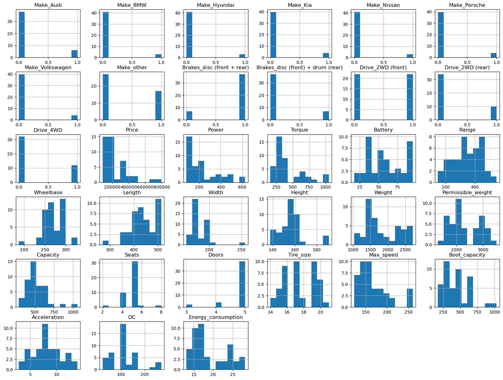

```python
df1.hist(figsize=(20, 15))
```

```python
df1.columns
```

```
Index(['Make_Audi', 'Make_BMW', 'Make_Hyundai', 'Make_Kia', 'Make_Nissan',
       'Make_Porsche', 'Make_Volkswagen', 'Make_other',
       'Brakes_disc (front + rear)', 'Brakes_disc (front) + drum (rear)',
       'Drive_2WD (front)', 'Drive_2WD (rear)', 'Drive_4WD', 'Price', 'Power',
       'Torque', 'Battery', 'Range', 'Wheelbase', 'Length', 'Width', 'Height',
       'Weight', 'Permissible_weight', 'Capacity', 'Seats', 'Doors',
       'Tire_size', 'Max_speed', 'Boot_capacity', 'Acceleration', 'DC',
       'Energy_consumption'],
      dtype='object')
```

```python
variaveis_nao_booleanas=['Price', 'Power',
       'Torque', 'Battery', 'Range', 'Wheelbase', 'Length', 'Width', 'Height',
       'Weight', 'Permissible_weight', 'Capacity', 'Seats', 'Doors',
       'Tire_size', 'Max_speed', 'Boot_capacity', 'Acceleration', 'DC',
       'Energy_consumption']
```

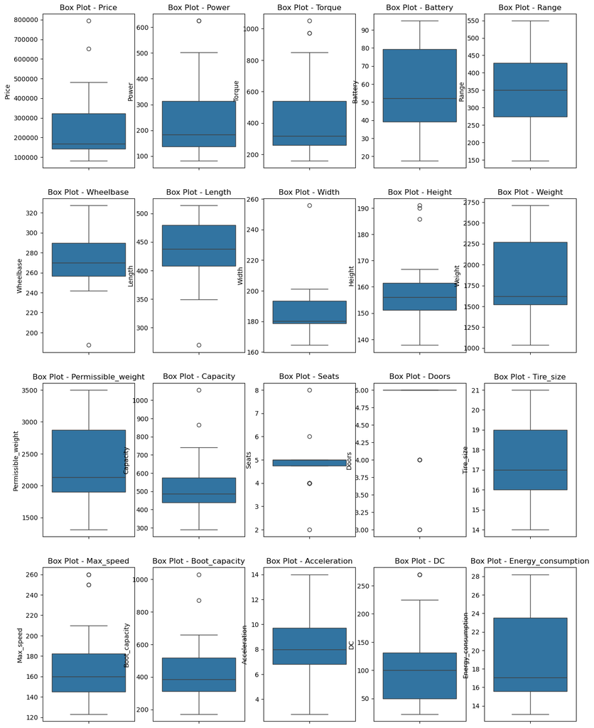

```python
n = len(variaveis_nao_booleanas)
cols = 5
rows = (n // cols) + (n % cols > 0)

# Cria a figura com subgráficos
fig, axes = plt.subplots(rows, cols, figsize=(15, rows * 5))

# Faz com que o axes seja 1D para facilitar iteração
axes = axes.flatten()

# Gera os boxplots
for i, col in enumerate(variaveis_nao_booleanas):
    sns.boxplot(y=df1[col], ax=axes[i])  # Coloca o gráfico no eixo correspondente
    axes[i].set_title(f'Box Plot - {col}')
```

Although some outliers are present, I believe they do not represent anomalies but rather genuine values that are above the average. Considering this, along with the fact that we have a limited number of samples, I decided to retain the outliers.

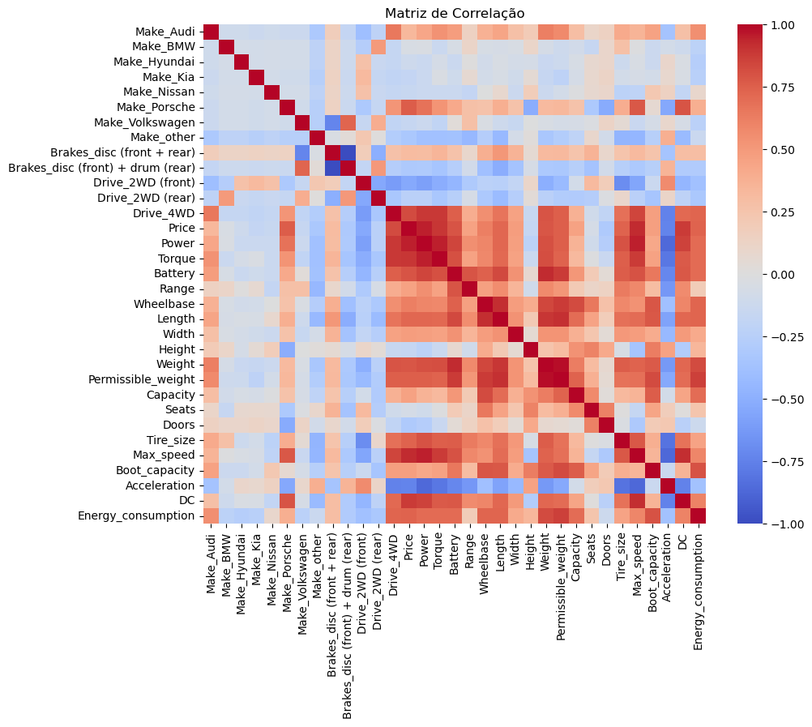

```python
# Creating a correlation matrix to analyze the relationships between numerical variables
# Displaying a heatmap of the correlation matrix with annotations to visually identify strong or weak correlations between features
corr = df1.corr()

# Cria o plot de correlação
plt.figure(figsize=(10, 8))
sns.heatmap(corr, annot=False, fmt=".2f", cmap='coolwarm')
plt.title('Matriz de Correlação')
plt.show()
```

Let's now prepare the data to feed the machine learning models.

```python
from sklearn.decomposition import PCA
from sklearn.preprocessing import StandardScaler
```

Since we have many variables, we will apply PCA to reduce the dimensionality. To do this, I will separate the numerical variables from the boolean ones to apply PCA only to the numerical variables.

```python
variaveis_nao_booleanas_sem_alvo=['Price', 'Power',
       'Torque', 'Battery', 'Range', 'Wheelbase', 'Length', 'Width', 'Height',
       'Weight', 'Permissible_weight', 'Capacity', 'Seats', 'Doors',
       'Tire_size', 'Max_speed', 'Boot_capacity', 'Acceleration', 'DC']
```

```python
df2=df1.copy()
```

```python
df2.columns
```

```
Index(['Make_Audi', 'Make_BMW', 'Make_Hyundai', 'Make_Kia', 'Make_Nissan',
       'Make_Porsche', 'Make_Volkswagen', 'Make_other',
       'Brakes_disc (front + rear)', 'Brakes_disc (front) + drum (rear)',
       'Drive_2WD (front)', 'Drive_2WD (rear)', 'Drive_4WD', 'Price', 'Power',
       'Torque', 'Battery', 'Range', 'Wheelbase', 'Length', 'Width', 'Height',
       'Weight', 'Permissible_weight', 'Capacity', 'Seats', 'Doors',
       'Tire_size', 'Max_speed', 'Boot_capacity', 'Acceleration', 'DC',
       'Energy_consumption'],
      dtype='object')
```

```python
#boolean variables
df2_bool=df2[['Make_Audi', 'Make_BMW', 'Make_Hyundai', 'Make_Kia', 'Make_Nissan',
       'Make_Porsche', 'Make_Volkswagen', 'Make_other',
       'Brakes_disc (front + rear)', 'Brakes_disc (front) + drum (rear)',
       'Drive_2WD (front)', 'Drive_2WD (rear)', 'Drive_4WD']]
```

```python
#Apllying Standarization
scaler = StandardScaler()
df2_scaled = scaler.fit_transform(df2[variaveis_nao_booleanas_sem_alvo])
df2_scaled=pd.DataFrame(df2_scaled,columns=variaveis_nao_booleanas_sem_alvo)
df2_scaled.head()
```

|  | Price | Power | Torque | Battery | Range | Wheelbase | Length | Width | Height | Weight | Permissible_weight | Capacity | Seats | Doors | Tire_size | Max_speed | Boot_capacity | Acceleration | DC |
| --- | --- | --- | --- | --- | --- | --- | --- | --- | --- | --- | --- | --- | --- | --- | --- | --- | --- | --- | --- |
| 0 | 0.732742 | 0.868042 | 1.073663 | 1.550551 | 0.932177 | 0.937285 | 1.103888 | 0.607543 | 0.556926 | 1.539785 | 1.500914 | 0.841605 | 0.260351 | 0.371391 | 0.838877 | 0.903929 | 1.266597 | -0.895385 | 0.693238 |
| 1 | 0.483979 | 0.544307 | 0.528387 | 0.513314 | -0.087236 | 0.937285 | 1.103888 | 0.607543 | 0.556926 | 1.286251 | 1.339060 | 1.055325 | 0.260351 | 0.371391 | 0.838877 | 0.619430 | 1.266597 | -0.489231 | 0.693238 |
| 2 | 1.194254 | 1.853022 | 2.432457 | 1.550551 | 0.162416 | 0.937285 | 1.105923 | 0.891482 | 0.556926 | 1.814446 | 1.500914 | 0.307304 | 0.260351 | 0.371391 | 1.389782 | 1.188427 | 1.266597 | -1.338463 | 0.693238 |
| 3 | 0.559342 | 0.544307 | 0.528387 | 0.513314 | -0.024823 | 0.937285 | 1.103888 | 0.607543 | 0.443800 | 1.286251 | 1.339060 | 0.841605 | 0.260351 | 0.371391 | 0.838877 | 0.619430 | 1.019711 | -0.489231 | 0.693238 |
| 4 | 0.808105 | 0.868042 | 1.073663 | 1.550551 | 1.025797 | 0.937285 | 1.103888 | 0.607543 | 0.443800 | 1.603168 | 1.500914 | 1.055325 | 0.260351 | 0.371391 | 0.838877 | 0.903929 | 1.019711 | -0.895385 | 0.693238 |

```python
df2_scaled.shape
```

```
(44, 19)
```

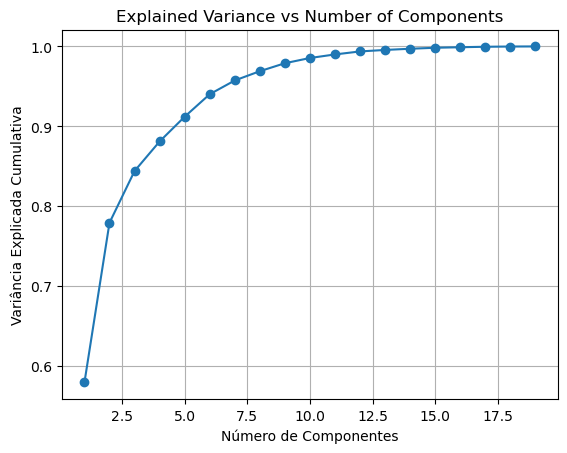

```python
#Determining the optimal number of components to retain for further analysis
pca = PCA()
pca.fit(df2_scaled)


var_exp = pca.explained_variance_ratio_


var_exp_cum = np.cumsum(var_exp)

# Plotting the cumulative explained variance graph
plt.plot(range(1, len(var_exp_cum)+1), var_exp_cum, marker='o')
plt.xlabel('Número de Componentes')
plt.ylabel('Variância Explicada Cumulativa')
plt.title('Explained Variance vs Number of Components')
plt.grid()
plt.show()
```

Lets use 8 as number os components

```python
# Applying PCA with 8 components to reduce the dimensionality of the numerical variables.
pca = PCA(n_components=8)


df2_scaled_pca = pca.fit_transform(df2_scaled)


df_pca = pd.DataFrame(df2_scaled_pca, columns=[f'PC{i+1}' for i in range(df2_scaled_pca.shape[1])])


df_pca.head(10)
```

|  | PC1 | PC2 | PC3 | PC4 | PC5 | PC6 | PC7 | PC8 |
| --- | --- | --- | --- | --- | --- | --- | --- | --- |
| 0 | 4.120517 | 0.773677 | 0.187345 | -0.561498 | 0.406875 | 0.087992 | -0.282150 | 0.163800 |
| 1 | 3.078809 | 1.180887 | -0.478137 | -0.030839 | 0.276433 | -0.341316 | 0.067181 | -0.460171 |
| 2 | 5.068241 | 0.030224 | -0.015377 | -0.514147 | 0.967806 | -1.423076 | -0.035070 | 0.598940 |
| 3 | 3.019507 | 0.979975 | -0.317689 | 0.009023 | 0.220703 | -0.387590 | 0.067430 | -0.384931 |
| 4 | 4.164742 | 0.700554 | 0.212005 | -0.480773 | 0.251165 | 0.174482 | -0.191684 | 0.150635 |
| 5 | 5.046385 | -0.112191 | 0.066527 | -0.441281 | 0.856143 | -1.417682 | 0.011792 | 0.621859 |
| 6 | -2.033806 | -0.868627 | 0.814223 | -0.402267 | 0.685999 | 0.134662 | 1.033415 | -0.908141 |
| 7 | -1.732459 | -0.997260 | 0.882403 | -0.478761 | 0.915149 | -0.075815 | 1.566555 | -0.970498 |
| 8 | 2.279614 | 0.719580 | 0.749639 | -0.487173 | 0.290299 | 0.631571 | 0.184615 | -0.091391 |
| 9 | -0.893359 | 0.168921 | 0.962471 | 4.354261 | 2.593859 | 0.577110 | -0.673337 | 0.017850 |

```python
df_pca.shape
```

```
(44, 8)
```

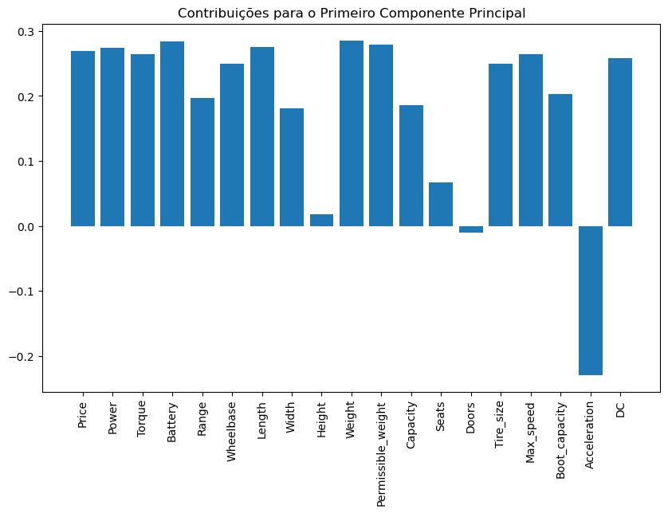

```python
# Plotting the contributions of each original feature to the first principal component.
plt.figure(figsize=(10, 6))
plt.bar(df2_scaled.columns, (pca.components_)[0])
plt.title('Contribuições para o Primeiro Componente Principal')
plt.xticks(rotation=90)
plt.show()
```

```python
df_pca.shape
```

```
(44, 8)
```

```python
df_finalfinal=pd.concat([df_pca,df2_bool,df2['Energy_consumption']], axis=1)
df_finalfinal.head(10)
```

|  | PC1 | PC2 | PC3 | PC4 | PC5 | PC6 | PC7 | PC8 | Make_Audi | Make_BMW | Make_Hyundai | Make_Kia | Make_Nissan | Make_Porsche | Make_Volkswagen | Make_other | Brakes_disc (front + rear) | Brakes_disc (front) + drum (rear) | Drive_2WD (front) | Drive_2WD (rear) | Drive_4WD | Energy_consumption |
| --- | --- | --- | --- | --- | --- | --- | --- | --- | --- | --- | --- | --- | --- | --- | --- | --- | --- | --- | --- | --- | --- | --- |
| 0 | 4.120517 | 0.773677 | 0.187345 | -0.561498 | 0.406875 | 0.087992 | -0.282150 | 0.163800 | 1 | 0 | 0 | 0 | 0 | 0 | 0 | 0 | 1 | 0 | 0 | 0 | 1 | 24.45 |
| 1 | 3.078809 | 1.180887 | -0.478137 | -0.030839 | 0.276433 | -0.341316 | 0.067181 | -0.460171 | 1 | 0 | 0 | 0 | 0 | 0 | 0 | 0 | 1 | 0 | 0 | 0 | 1 | 23.80 |
| 2 | 5.068241 | 0.030224 | -0.015377 | -0.514147 | 0.967806 | -1.423076 | -0.035070 | 0.598940 | 1 | 0 | 0 | 0 | 0 | 0 | 0 | 0 | 1 | 0 | 0 | 0 | 1 | 27.55 |
| 3 | 3.019507 | 0.979975 | -0.317689 | 0.009023 | 0.220703 | -0.387590 | 0.067430 | -0.384931 | 1 | 0 | 0 | 0 | 0 | 0 | 0 | 0 | 1 | 0 | 0 | 0 | 1 | 23.30 |
| 4 | 4.164742 | 0.700554 | 0.212005 | -0.480773 | 0.251165 | 0.174482 | -0.191684 | 0.150635 | 1 | 0 | 0 | 0 | 0 | 0 | 0 | 0 | 1 | 0 | 0 | 0 | 1 | 23.85 |
| 5 | 5.046385 | -0.112191 | 0.066527 | -0.441281 | 0.856143 | -1.417682 | 0.011792 | 0.621859 | 1 | 0 | 0 | 0 | 0 | 0 | 0 | 0 | 1 | 0 | 0 | 0 | 1 | 27.20 |
| 6 | -2.033806 | -0.868627 | 0.814223 | -0.402267 | 0.685999 | 0.134662 | 1.033415 | -0.908141 | 0 | 1 | 0 | 0 | 0 | 0 | 0 | 0 | 1 | 0 | 0 | 1 | 0 | 13.10 |
| 7 | -1.732459 | -0.997260 | 0.882403 | -0.478761 | 0.915149 | -0.075815 | 1.566555 | -0.970498 | 0 | 1 | 0 | 0 | 0 | 0 | 0 | 0 | 1 | 0 | 0 | 1 | 0 | 14.30 |
| 8 | 2.279614 | 0.719580 | 0.749639 | -0.487173 | 0.290299 | 0.631571 | 0.184615 | -0.091391 | 0 | 1 | 0 | 0 | 0 | 0 | 0 | 0 | 1 | 0 | 0 | 1 | 0 | 18.80 |
| 9 | -0.893359 | 0.168921 | 0.962471 | 4.354261 | 2.593859 | 0.577110 | -0.673337 | 0.017850 | 0 | 0 | 0 | 0 | 0 | 0 | 0 | 1 | 1 | 0 | 1 | 0 | 0 | 15.60 |

```python
df_finalfinal.shape
```

```
(44, 22)
```

I'm not sure if the boolean variables will help with the model's prediction, so I will train the model with three different types of dataframes:

- With all the variables
- Only the PCA components
- PCA components plus the boolean variables, excluding the 'Make' variable, as I don't think it will interfere much either.

```python
df_finalfinal.columns
```

```
Index(['PC1', 'PC2', 'PC3', 'PC4', 'PC5', 'PC6', 'PC7', 'PC8', 'Make_Audi',
       'Make_BMW', 'Make_Hyundai', 'Make_Kia', 'Make_Nissan', 'Make_Porsche',
       'Make_Volkswagen', 'Make_other', 'Brakes_disc (front + rear)',
       'Brakes_disc (front) + drum (rear)', 'Drive_2WD (front)',
       'Drive_2WD (rear)', 'Drive_4WD', 'Energy_consumption'],
      dtype='object')
```

```python
df_final_PCs=df_finalfinal.drop(columns=['Make_Audi',
       'Make_BMW', 'Make_Hyundai', 'Make_Kia', 'Make_Nissan', 'Make_Porsche',
       'Make_Volkswagen', 'Make_other', 'Brakes_disc (front + rear)',
       'Brakes_disc (front) + drum (rear)', 'Drive_2WD (front)',
       'Drive_2WD (rear)', 'Drive_4WD'],axis=1)
df_final_sem_make=df_finalfinal.drop(columns=['Make_Audi',
       'Make_BMW', 'Make_Hyundai', 'Make_Kia', 'Make_Nissan', 'Make_Porsche',
       'Make_Volkswagen', 'Make_other'],axis=1)
```

```python
df_final_PCs.head(10)
```

|  | PC1 | PC2 | PC3 | PC4 | PC5 | PC6 | PC7 | PC8 | Energy_consumption |
| --- | --- | --- | --- | --- | --- | --- | --- | --- | --- |
| 0 | 4.120517 | 0.773677 | 0.187345 | -0.561498 | 0.406875 | 0.087992 | -0.282150 | 0.163800 | 24.45 |
| 1 | 3.078809 | 1.180887 | -0.478137 | -0.030839 | 0.276433 | -0.341316 | 0.067181 | -0.460171 | 23.80 |
| 2 | 5.068241 | 0.030224 | -0.015377 | -0.514147 | 0.967806 | -1.423076 | -0.035070 | 0.598940 | 27.55 |
| 3 | 3.019507 | 0.979975 | -0.317689 | 0.009023 | 0.220703 | -0.387590 | 0.067430 | -0.384931 | 23.30 |
| 4 | 4.164742 | 0.700554 | 0.212005 | -0.480773 | 0.251165 | 0.174482 | -0.191684 | 0.150635 | 23.85 |
| 5 | 5.046385 | -0.112191 | 0.066527 | -0.441281 | 0.856143 | -1.417682 | 0.011792 | 0.621859 | 27.20 |
| 6 | -2.033806 | -0.868627 | 0.814223 | -0.402267 | 0.685999 | 0.134662 | 1.033415 | -0.908141 | 13.10 |
| 7 | -1.732459 | -0.997260 | 0.882403 | -0.478761 | 0.915149 | -0.075815 | 1.566555 | -0.970498 | 14.30 |
| 8 | 2.279614 | 0.719580 | 0.749639 | -0.487173 | 0.290299 | 0.631571 | 0.184615 | -0.091391 | 18.80 |
| 9 | -0.893359 | 0.168921 | 0.962471 | 4.354261 | 2.593859 | 0.577110 | -0.673337 | 0.017850 | 15.60 |

```python
df_final_sem_make.head(10)
```

|  | PC1 | PC2 | PC3 | PC4 | PC5 | PC6 | PC7 | PC8 | Brakes_disc (front + rear) | Brakes_disc (front) + drum (rear) | Drive_2WD (front) | Drive_2WD (rear) | Drive_4WD | Energy_consumption |
| --- | --- | --- | --- | --- | --- | --- | --- | --- | --- | --- | --- | --- | --- | --- |
| 0 | 4.120517 | 0.773677 | 0.187345 | -0.561498 | 0.406875 | 0.087992 | -0.282150 | 0.163800 | 1 | 0 | 0 | 0 | 1 | 24.45 |
| 1 | 3.078809 | 1.180887 | -0.478137 | -0.030839 | 0.276433 | -0.341316 | 0.067181 | -0.460171 | 1 | 0 | 0 | 0 | 1 | 23.80 |
| 2 | 5.068241 | 0.030224 | -0.015377 | -0.514147 | 0.967806 | -1.423076 | -0.035070 | 0.598940 | 1 | 0 | 0 | 0 | 1 | 27.55 |
| 3 | 3.019507 | 0.979975 | -0.317689 | 0.009023 | 0.220703 | -0.387590 | 0.067430 | -0.384931 | 1 | 0 | 0 | 0 | 1 | 23.30 |
| 4 | 4.164742 | 0.700554 | 0.212005 | -0.480773 | 0.251165 | 0.174482 | -0.191684 | 0.150635 | 1 | 0 | 0 | 0 | 1 | 23.85 |
| 5 | 5.046385 | -0.112191 | 0.066527 | -0.441281 | 0.856143 | -1.417682 | 0.011792 | 0.621859 | 1 | 0 | 0 | 0 | 1 | 27.20 |
| 6 | -2.033806 | -0.868627 | 0.814223 | -0.402267 | 0.685999 | 0.134662 | 1.033415 | -0.908141 | 1 | 0 | 0 | 1 | 0 | 13.10 |
| 7 | -1.732459 | -0.997260 | 0.882403 | -0.478761 | 0.915149 | -0.075815 | 1.566555 | -0.970498 | 1 | 0 | 0 | 1 | 0 | 14.30 |
| 8 | 2.279614 | 0.719580 | 0.749639 | -0.487173 | 0.290299 | 0.631571 | 0.184615 | -0.091391 | 1 | 0 | 0 | 1 | 0 | 18.80 |
| 9 | -0.893359 | 0.168921 | 0.962471 | 4.354261 | 2.593859 | 0.577110 | -0.673337 | 0.017850 | 1 | 0 | 1 | 0 | 0 | 15.60 |

```python
from sklearn.ensemble import RandomForestRegressor
from sklearn.model_selection import GridSearchCV
from sklearn.metrics import mean_squared_error
from sklearn.model_selection import train_test_split
from sklearn.linear_model import LinearRegression
```

```python
# Defining the target variable and creating feature sets by removing 'Energy_consumption' from the dataframes.
y=df_finalfinal['Energy_consumption']
X_todas_var=df_finalfinal.drop('Energy_consumption',axis=1)
X_somente_PCs=df_final_PCs.drop('Energy_consumption',axis=1)
X_sem_make=df_final_sem_make.drop('Energy_consumption',axis=1)
```

```python
X_todas_var.isna().sum()
```

```
PC1                                  0
PC2                                  0
PC3                                  0
PC4                                  0
PC5                                  0
PC6                                  0
PC7                                  0
PC8                                  0
Make_Audi                            0
Make_BMW                             0
Make_Hyundai                         0
Make_Kia                             0
Make_Nissan                          0
Make_Porsche                         0
Make_Volkswagen                      0
Make_other                           0
Brakes_disc (front + rear)           0
Brakes_disc (front) + drum (rear)    0
Drive_2WD (front)                    0
Drive_2WD (rear)                     0
Drive_4WD                            0
dtype: int64
```

```python
# Creating a function that Splits the data into training and testing sets (70% train, 30% test).
def preprocess_data(X, y):

    X_train, X_test, y_train, y_test = train_test_split(X, y, test_size=0.3, random_state=42)
    return X_train, X_test, y_train, y_test
```

Our base model will be Linear Regression

```python
# Function for training the model and evaluating it using Mean Squared Error (MSE).
def train_and_evaluate(X_train, X_test, y_train, y_test):

    model = LinearRegression()


    model.fit(X_train, y_train)


    y_pred = model.predict(X_test)


    mse = mean_squared_error(y_test, y_pred)

    return model, mse
```

```python
#Applying the functions and calculating the metrics
results = {}

for group, X_data in {'todas_var': X_todas_var, 'somente_PCs': X_somente_PCs, 'sem_make': X_sem_make}.items():
    print(f"Processando {group}...")


    y = df_finalfinal['Energy_consumption']


    X_train, X_test, y_train, y_test = preprocess_data(X_data, y)


    model, mse = train_and_evaluate(X_train, X_test, y_train, y_test)


    results[group] = {'model': model, 'mse': mse}


print("\nResultados de cada grupo de dados:")
for group, result in results.items():
    print(f"{group} -> MSE: {result['mse']}")
```

```
Processando todas_var...
Processando somente_PCs...
Processando sem_make...

Resultados de cada grupo de dados:
todas_var -> MSE: 2.5313670738370173
somente_PCs -> MSE: 1.5019039665072358
sem_make -> MSE: 2.252777328163646
```

```python
#Doing the same for Ensemble model with GridSearchCV

def train_and_evaluate(X_train, X_test, y_train, y_test):

    rf = RandomForestRegressor(random_state=42)


    param_grid = {
        'n_estimators': [50, 100, 200],  # Número de árvores
        'max_depth': [10, 20, 30],  # Profundidade máxima da árvore
        'min_samples_split': [2, 5, 10],  # Mínimo de amostras para dividir um nó
        'min_samples_leaf': [1, 2, 4],  # Mínimo de amostras por folha
        'max_features': [ 'sqrt', 'log2'],  # Estratégia para selecionar as variáveis
    }


    grid_search = GridSearchCV(estimator=rf, param_grid=param_grid, cv=5, n_jobs=-1, verbose=1, scoring='neg_mean_squared_error')


    grid_search.fit(X_train, y_train)


    y_pred = grid_search.predict(X_test)


    mse = mean_squared_error(y_test, y_pred)

    return grid_search.best_params_, mse
```

```python
for group, X_data in {'todas_var': X_todas_var, 'somente_PCs': X_somente_PCs, 'sem_make': X_sem_make}.items():
    print(f"Processando {group}...")



    X_train, X_test, y_train, y_test = preprocess_data(X_data, y)


    best_params, mse = train_and_evaluate(X_train, X_test, y_train, y_test)


    results[group] = {'best_params': best_params, 'mse': mse}


print("\nResultados de cada grupo de dados:")
for group, result in results.items():
    print(f"{group} -> Melhor parâmetro: {result['best_params']}, MSE: {result['mse']}")
```

```
Processando todas_var...
Fitting 5 folds for each of 162 candidates, totalling 810 fits
```

```
Processando somente_PCs...
Fitting 5 folds for each of 162 candidates, totalling 810 fits
Processando sem_make...
Fitting 5 folds for each of 162 candidates, totalling 810 fits
```

```
Resultados de cada grupo de dados:
todas_var -> Melhor parâmetro: {'max_depth': 10, 'max_features': 'sqrt', 'min_samples_leaf': 1, 'min_samples_split': 2, 'n_estimators': 200}, MSE: 3.8854639945436356
somente_PCs -> Melhor parâmetro: {'max_depth': 10, 'max_features': 'sqrt', 'min_samples_leaf': 1, 'min_samples_split': 2, 'n_estimators': 50}, MSE: 5.548071142857147
sem_make -> Melhor parâmetro: {'max_depth': 10, 'max_features': 'sqrt', 'min_samples_leaf': 1, 'min_samples_split': 2, 'n_estimators': 200}, MSE: 4.194959678571435
```

# Next Steps

To enhance my analysis and improve model performance, I plan to take the following steps:

- Simpler Models: I will explore simpler machine learning models, such as K-Nearest Neighbors (KNN) Regression, which might perform better given the small dataset size.
- Feature Selection Instead of PCA: Instead of relying solely on PCA for dimensionality reduction, I will test feature selection techniques, such as importance-based selection or statistical tests like ANOVA, to identify the most relevant variables.
- Dataset Expansion: I will look into acquiring additional data to expand my dataset. Increasing the number of samples is crucial for enhancing the robustness and reliability of machine learning models.
- Alternative Metrics: I plan to evaluate model performance using additional metrics, such as R² (coefficient of determination) or MAE (mean absolute error), to gain more insights into model accuracy and reliability.
- Validation Strategy: I will implement more robust validation techniques, such as Leave-One-Out Cross-Validation (LOOCV) or other suitable cross-validation methods, to ensure reliable model evaluation.
- Regularized Regression Models: I intend to experiment with regularized models, like Ridge Regression or Lasso Regression, to address potential overfitting and improve model performance in small datasets.
- Stability of PCA: I will reassess the stability of the principal components generated during PCA by testing different numbers of components and evaluating their impact on model performance.

By following these steps, I aim to refine my approach, address the limitations of my dataset, and build a more robust and generalizable predictive model.